# M2.851 - Tipología y ciclo de vida de los datos

María del Mar Colino García

14 de mayo de 2019

# Práctica 2 - Limpieza y validación de los datos

## Definición del problema a resolver - *problem statement*

A partir del conjunto de datos sobre vinos se plantea realizar un análisis y estudio sobre las características de los vinos con el fin de entender cómo influyen sobre su calidad. Disponer de este tipo de información es de gran utilidad a cualquier productor de vino que desee entender las características que más afectan a la calidad del vino, y como afectan, de cara a establecer estrategias para mejorar su producción.

Adicionalmente, a partir de la información disponible en este conjunto de datos podrán construirse modelos de regresión y/o clasificación que permitan predecir la calidad de nuevas observaciones de vinos en base a sus características. También será viable llevar a cabo contrastes de hipótesis para ayudar a identificar propiedades que pueden resultar interesantes en las muestras y que puedan ser inferidas con respecto a la población.

## Selección, recuperación y persitencia de los datos – *data collection and storage*

El conjunto de datos escogido para llevar a cabo la ejecución de esta práctica se llama **Red Wine Quality** y podemos encontrarlo en el repositorio UCI: https://archive.ics.uci.edu/ml/datasets/wine+quality, es uno de los propuestos en enunciado de la práctica.

Este conjunto de datos está compuesto por dos *datasets*, disponiéndose de un total de 6497 observaciones con 12 atributos cada una. La información incluida en estas muestras describe una serie de características asociadas a vinos (tinto y blanco) y la calidad que le ha sido asignada.

El conjunto de atributos que forman parte del dataset son:

1. **fixed acidity**: acidez fija, la mayoría de los ácidos relacionados con el vino, o fijos, o no volátiles (no se evaporan fácilmente) (tartaric acid - g / l)
2. **volatile acidity**: acidez fija, la cantidad de ácido acético en el vino, que a niveles demasiado altos puede provocar un sabor desagradable a vinagre (acetic acid - g / l)
3. **citric acid**: ácido cítrico, se encuentra en pequeñas cantidades, el ácido cítrico puede agregar “frescura” y sabor a los vinos (g / l)
4. **residual sugar**: azucar resiual, la cantidad de azúcar restante después de que se detenga la fermentación (g / l)
5. **chlorides**: cloruros, la cantidad de sal en el vino (sodium chloride - g / l
6. **free sulfur dioxide**: dióxido de azufre libre, la forma libre de SO2 existe en equilibrio entre el SO2 molecular (como un gas disuelto) y el ión bisulfito (mg / l)
7. **total sulfur dioxide**: dióxido de azufre total, cantidad de formas libres y unidas de S02 (mg / l)
8. **density**: densidad, la densidad del agua es cercana a la del agua según el porcentaje de alcohol y contenido de azúcar (g / l)
9. **pH**: describe qué tan ácido o básico es un vino en una escala de 0 (muy ácido) a 14 (muy básico)
10. **sulphates**: sultafos, un aditivo de vino que puede contribuir a los niveles de gas de dióxido de azufre (S02) (potassium sulphate - g / l)
11. **alcohol**: el porcentaje de contenido de alcohol del vino (% por volumen)
12. **quality**: calidad asignada al vino, puntuación de 0 a 10

Los autores y propietarios del dataset son (P. Cortez, 2009)

## Pre-procesado de los datos – *data preprocesing*

### Integración

Antes de nada, se procederá a instalar y configurar las dependencias que van a ser usadas a lo largo del proceso analítico.

```r
# importar dependencias requeridas
if(!require(Rcpp)){
  install.packages('Rcpp', repos='http://cran.us.r-project.org')
  library('Rcpp')
}
if(!require(colorspace)){
  install.packages('colorspace', repos='http://cran.us.r-project.org')
  library('colorspace')
}
if(!require(RColorBrewer)){
  install.packages('RColorBrewer', repos='http://cran.us.r-project.org')
  library('RColorBrewer')
}
if(!require(ggplot2)){
  install.packages('ggplot2', repos='http://cran.us.r-project.org')
  library('ggplot2')
}
if(!require(GGally)){
  install.packages('GGally', repos='http://cran.us.r-project.org')
  library('GGally')
}
if(!require(knitr)){
  install.packages('knitr', repos='http://cran.us.r-project.org')
  library('knitr')
}
if(!require(VIM)){
  install.packages('VIM', repos='http://cran.us.r-project.org')
  library('VIM')
}
if(!require(missForest)){
  install.packages('missForest', repos='http://cran.us.r-project.org')
  library('missForest')
}
if(!require(dplyr)){
  install.packages('dplyr', repos='http://cran.us.r-project.org')
  library(dplyr)
}
if(!require(caret)){
  install.packages('caret', repos='http://cran.us.r-project.org')
  library(caret)
}
if(!require(plyr)){
  install.packages('plyr', repos='http://cran.us.r-project.org')
  library(plyr)
}
if(!require(gridExtra)){
    install.packages('gridExtra', repos='http://cran.us.r-project.org')
    library(gridExtra)
}
if(!require(nortest)){
    install.packages('nortest', repos='http://cran.us.r-project.org')
    library(nortest)
}
if(!require(corrplot)){
  install.packages('corrplot', repos='http://cran.us.r-project.org')
  library('corrplot')
}
if(!require(caTools)){
    install.packages('caTools', repos='http://cran.us.r-project.org')
    library(caTools)
}
if(!require(rpart)){
  install.packages('rpart', repos='http://cran.us.r-project.org')
  library(rpart)
}
if(!require(rpart.plot)){
  install.packages('rpart.plot', repos='http://cran.us.r-project.org')
  library(rpart.plot)
}
```

Antes de proceder a las tareas de integración, será necesario realizar la carga de los datos. Como se ha indicado en el apartado Selección, recuperación y persitencia de los datos, contamos con dos *datasets* de partida, uno para vinos tintos y otro para vinos blancos, en principio vamos a fusionar los datos de ambos *datasets* añadiendo una nueva propiedad para indicar el tipo del vino al que pertenece cada observación. De esta forma contaremos con un juego de datos lo más completo posible que nos permita realizar análisis considerando todos los ámbitos asociados a una observación.

```r
# Cargamos el dataset para vinos tintos
wine_quality_red = read.csv("https://archive.ics.uci.edu/ml/machine-learning-databases/wine-quality/winequality-red.csv", header=TRUE, sep = ';')
wine_quality_white = read.csv("https://archive.ics.uci.edu/ml/machine-learning-databases/wine-quality/winequality-white.csv", header=TRUE, sep = ';')
```

Previo a realizar la integración de los datos, echamos un vistazo a los datos cargados, para asegurarnos que está todo en orden.

En primer lugar, visualizamos el contenido:

```r
# Echamos un vistazo al dataset
head(wine_quality_red)
```

```
##   fixed.acidity volatile.acidity citric.acid residual.sugar chlorides
## 1           7.4             0.70        0.00            1.9     0.076
## 2           7.8             0.88        0.00            2.6     0.098
## 3           7.8             0.76        0.04            2.3     0.092
## 4          11.2             0.28        0.56            1.9     0.075
## 5           7.4             0.70        0.00            1.9     0.076
## 6           7.4             0.66        0.00            1.8     0.075
##   free.sulfur.dioxide total.sulfur.dioxide density   pH sulphates alcohol
## 1                  11                   34  0.9978 3.51      0.56     9.4
## 2                  25                   67  0.9968 3.20      0.68     9.8
## 3                  15                   54  0.9970 3.26      0.65     9.8
## 4                  17                   60  0.9980 3.16      0.58     9.8
## 5                  11                   34  0.9978 3.51      0.56     9.4
## 6                  13                   40  0.9978 3.51      0.56     9.4
##   quality
## 1       5
## 2       5
## 3       5
## 4       6
## 5       5
## 6       5
```

Y a continuación la estructura:

```r
# Mostramos información sobre la estructura
str(wine_quality_red)
```

```
## 'data.frame':    1599 obs. of  12 variables:
##  $ fixed.acidity       : num  7.4 7.8 7.8 11.2 7.4 7.4 7.9 7.3 7.8 7.5 ...
##  $ volatile.acidity    : num  0.7 0.88 0.76 0.28 0.7 0.66 0.6 0.65 0.58 0.5 ...
##  $ citric.acid         : num  0 0 0.04 0.56 0 0 0.06 0 0.02 0.36 ...
##  $ residual.sugar      : num  1.9 2.6 2.3 1.9 1.9 1.8 1.6 1.2 2 6.1 ...
##  $ chlorides           : num  0.076 0.098 0.092 0.075 0.076 0.075 0.069 0.065 0.073 0.071 ...
##  $ free.sulfur.dioxide : num  11 25 15 17 11 13 15 15 9 17 ...
##  $ total.sulfur.dioxide: num  34 67 54 60 34 40 59 21 18 102 ...
##  $ density             : num  0.998 0.997 0.997 0.998 0.998 ...
##  $ pH                  : num  3.51 3.2 3.26 3.16 3.51 3.51 3.3 3.39 3.36 3.35 ...
##  $ sulphates           : num  0.56 0.68 0.65 0.58 0.56 0.56 0.46 0.47 0.57 0.8 ...
##  $ alcohol             : num  9.4 9.8 9.8 9.8 9.4 9.4 9.4 10 9.5 10.5 ...
##  $ quality             : int  5 5 5 6 5 5 5 7 7 5 ...
```

Contamos con 1599 observaciones de vinos tintos.

Y ahora al dataset para vino blanco:

```r
# Echamos un vistazo al dataset
head(wine_quality_white)
```

```
##   fixed.acidity volatile.acidity citric.acid residual.sugar chlorides
## 1           7.0             0.27        0.36           20.7     0.045
## 2           6.3             0.30        0.34            1.6     0.049
## 3           8.1             0.28        0.40            6.9     0.050
## 4           7.2             0.23        0.32            8.5     0.058
## 5           7.2             0.23        0.32            8.5     0.058
## 6           8.1             0.28        0.40            6.9     0.050
##   free.sulfur.dioxide total.sulfur.dioxide density   pH sulphates alcohol
## 1                  45                  170  1.0010 3.00      0.45     8.8
## 2                  14                  132  0.9940 3.30      0.49     9.5
## 3                  30                   97  0.9951 3.26      0.44    10.1
## 4                  47                  186  0.9956 3.19      0.40     9.9
## 5                  47                  186  0.9956 3.19      0.40     9.9
## 6                  30                   97  0.9951 3.26      0.44    10.1
##   quality
## 1       6
## 2       6
## 3       6
## 4       6
## 5       6
## 6       6
```

```r
str(wine_quality_white)
```

```
## 'data.frame':    4898 obs. of  12 variables:
##  $ fixed.acidity       : num  7 6.3 8.1 7.2 7.2 8.1 6.2 7 6.3 8.1 ...
##  $ volatile.acidity    : num  0.27 0.3 0.28 0.23 0.23 0.28 0.32 0.27 0.3 0.22 ...
##  $ citric.acid         : num  0.36 0.34 0.4 0.32 0.32 0.4 0.16 0.36 0.34 0.43 ...
##  $ residual.sugar      : num  20.7 1.6 6.9 8.5 8.5 6.9 7 20.7 1.6 1.5 ...
##  $ chlorides           : num  0.045 0.049 0.05 0.058 0.058 0.05 0.045 0.045 0.049 0.044 ...
##  $ free.sulfur.dioxide : num  45 14 30 47 47 30 30 45 14 28 ...
##  $ total.sulfur.dioxide: num  170 132 97 186 186 97 136 170 132 129 ...
##  $ density             : num  1.001 0.994 0.995 0.996 0.996 ...
##  $ pH                  : num  3 3.3 3.26 3.19 3.19 3.26 3.18 3 3.3 3.22 ...
##  $ sulphates           : num  0.45 0.49 0.44 0.4 0.4 0.44 0.47 0.45 0.49 0.45 ...
##  $ alcohol             : num  8.8 9.5 10.1 9.9 9.9 10.1 9.6 8.8 9.5 11 ...
##  $ quality             : int  6 6 6 6 6 6 6 6 6 6 ...
```

Contamos con 4898 observaciones de vinos blancos. Parece que está todo en orden, los datos tienen el formato esperado, por lo que podemos proceder a su integración:

```r
# Asignamos etiqueta
wine_quality_red$type = 'red'
wine_quality_white$type = 'white'
# Creamos un único dataset a partir de los dataset para vino tinto y blanco
wine_quality.base = rbind(wine_quality_red, wine_quality_white)
# Establecemos el valor de la etiqueta como factor
wine_quality.base$type = as.factor(wine_quality.base$type)
```

Una vez realizada la integración, verificamos que el resultado es el esperado:

```r
# Mostramos la estructura del dataset resultante
str(wine_quality.base)
```

```
## 'data.frame':    6497 obs. of  13 variables:
##  $ fixed.acidity       : num  7.4 7.8 7.8 11.2 7.4 7.4 7.9 7.3 7.8 7.5 ...
##  $ volatile.acidity    : num  0.7 0.88 0.76 0.28 0.7 0.66 0.6 0.65 0.58 0.5 ...
##  $ citric.acid         : num  0 0 0.04 0.56 0 0 0.06 0 0.02 0.36 ...
##  $ residual.sugar      : num  1.9 2.6 2.3 1.9 1.9 1.8 1.6 1.2 2 6.1 ...
##  $ chlorides           : num  0.076 0.098 0.092 0.075 0.076 0.075 0.069 0.065 0.073 0.071 ...
##  $ free.sulfur.dioxide : num  11 25 15 17 11 13 15 15 9 17 ...
##  $ total.sulfur.dioxide: num  34 67 54 60 34 40 59 21 18 102 ...
##  $ density             : num  0.998 0.997 0.997 0.998 0.998 ...
##  $ pH                  : num  3.51 3.2 3.26 3.16 3.51 3.51 3.3 3.39 3.36 3.35 ...
##  $ sulphates           : num  0.56 0.68 0.65 0.58 0.56 0.56 0.46 0.47 0.57 0.8 ...
##  $ alcohol             : num  9.4 9.8 9.8 9.8 9.4 9.4 9.4 10 9.5 10.5 ...
##  $ quality             : int  5 5 5 6 5 5 5 7 7 5 ...
##  $ type                : Factor w/ 2 levels "red","white": 1 1 1 1 1 1 1 1 1 1 ...
```

El resultado es el esperado, obtenemos un nuevo dataset con 6497 observaciones y 13 variables.

Aunque es muy probable que las características de los vinos tintos difieran de las características de los vinos blancos, al menos en parte, el incluir dentro de un único dataset el conjunto completo de observaciones de vino, tinto y blanco, nos permitirá tener un acceso centralizado en cualquier momento a todo el conjunto de datos de partida.

En cualquier caso, con el objetivo de entender las características de los datos por tipo de vino, y poder adquirir una visión general de los datos que nos permita tener un poco más de criterio a la hora de ejecutar los siguientes pasos del proceso, vamos a hacer una mínima exploración (o *screening*) de los datos.

En primer lugar, visualizamos algunos estadísticos descriptivos:

```r
summary(wine_quality.base)
```

```
##  fixed.acidity    volatile.acidity  citric.acid     residual.sugar
##  Min.   : 3.800   Min.   :0.0800   Min.   :0.0000   Min.   : 0.600
##  1st Qu.: 6.400   1st Qu.:0.2300   1st Qu.:0.2500   1st Qu.: 1.800
##  Median : 7.000   Median :0.2900   Median :0.3100   Median : 3.000
##  Mean   : 7.215   Mean   :0.3397   Mean   :0.3186   Mean   : 5.443
##  3rd Qu.: 7.700   3rd Qu.:0.4000   3rd Qu.:0.3900   3rd Qu.: 8.100
##  Max.   :15.900   Max.   :1.5800   Max.   :1.6600   Max.   :65.800
##    chlorides       free.sulfur.dioxide total.sulfur.dioxide
##  Min.   :0.00900   Min.   :  1.00      Min.   :  6.0
##  1st Qu.:0.03800   1st Qu.: 17.00      1st Qu.: 77.0
##  Median :0.04700   Median : 29.00      Median :118.0
##  Mean   :0.05603   Mean   : 30.53      Mean   :115.7
##  3rd Qu.:0.06500   3rd Qu.: 41.00      3rd Qu.:156.0
##  Max.   :0.61100   Max.   :289.00      Max.   :440.0
##     density             pH          sulphates         alcohol
##  Min.   :0.9871   Min.   :2.720   Min.   :0.2200   Min.   : 8.00
##  1st Qu.:0.9923   1st Qu.:3.110   1st Qu.:0.4300   1st Qu.: 9.50
##  Median :0.9949   Median :3.210   Median :0.5100   Median :10.30
##  Mean   :0.9947   Mean   :3.219   Mean   :0.5313   Mean   :10.49
##  3rd Qu.:0.9970   3rd Qu.:3.320   3rd Qu.:0.6000   3rd Qu.:11.30
##  Max.   :1.0390   Max.   :4.010   Max.   :2.0000   Max.   :14.90
##     quality         type
##  Min.   :3.000   red  :1599
##  1st Qu.:5.000   white:4898
##  Median :6.000
##  Mean   :5.818
##  3rd Qu.:6.000
##  Max.   :9.000
```

A continuación, vamos a hacer uso de un diagrama que nos permite visualizar gran cantidad de información sobre la distribución de los datos, aprovecharemos para agruparlo por tipo de vino, para confirmar nuestra sospecha sobre que pueden existir diferencias en como se distribuyen las características en función del tipo de vino.

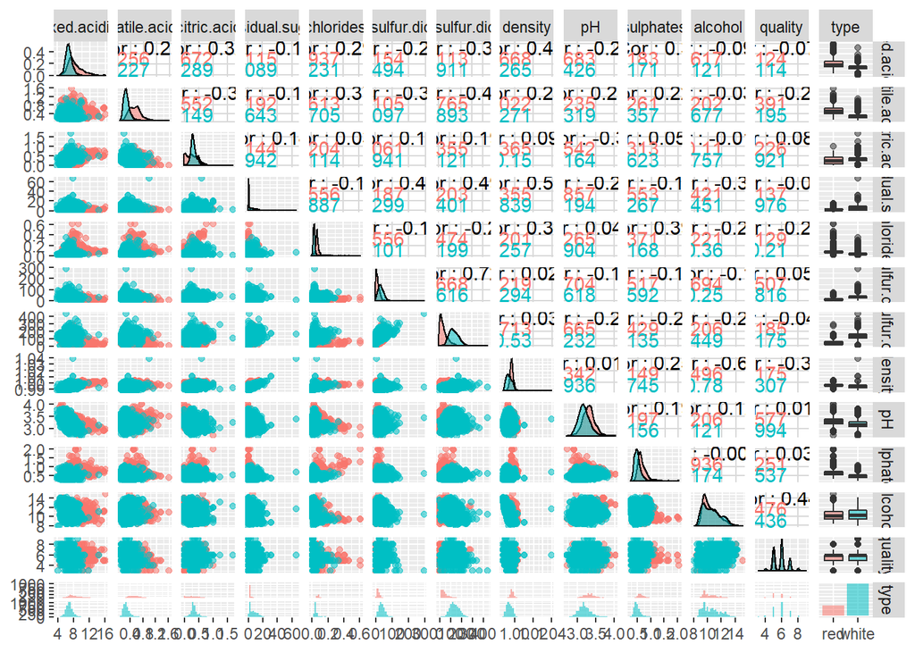

```r
ggpairs(wine_quality.base, aes(colour = type, alpha = 0.4))
```

Como se observa, en un mismo gráfico, y agrupado por tipo de vino, disponemos de gráficos por pares de características, *boxplots*, diagramas de densidad, algo que nos facilita enormemente tener una visión preliminar. Al observar el gráfico, rápidamente podemos confirmar la existencia de una diferencia en el comportamiento de las características en base al tipo de vino, además, de este gráfico también pueden observarse relaciones entre cada característica y la calidad resultante, en función del tipo de vino.

Finalmente, vamos a usar **PCA** (*Principal Component Analisys*) para obtener una representación multidimensional simplificada de los datos, que puede ser usada para visualízalos. El propósito de PCA es, encontrar la mejor representación, con la menor dimensionalidad, que pueda recoger la mayor parte de la variabilidad del conjunto de datos.

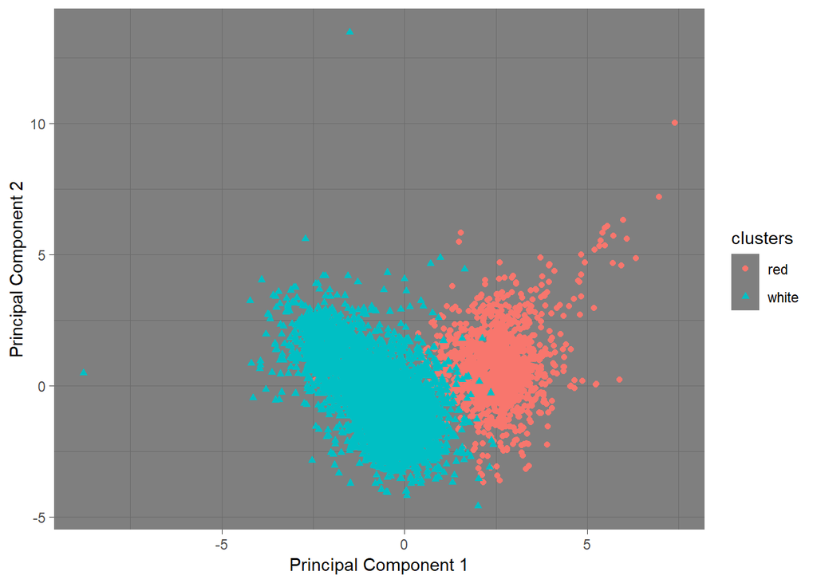

```r
## Realiza un plot PCA de los datos clusterizados
plotClusterPCA = function(dataset.stand, dataset.clusters, attCluster, shape="clusters", scaled=TRUE) {
  # si no se suministra el data set estandarizado se estandariza
  if(!scaled) {
    dataset.stand = as.data.frame(scale(dataset.stand))
  }
  ### Construcción componentes principales
  prin_comp <- princomp(dataset.stand)
  nComp = 2
  ### Project cluster on 2 principal componentes
  project = predict(prin_comp, newdata=dataset.stand)[,1:nComp]

  ### Crear data frame con los datos usados para realizar plot
  project_data = cbind(as.data.frame(project),
                        cluster = as.factor(dataset.clusters[[attCluster]]))

  ### Construir plot
  ggplot(project_data, aes(x=Comp.1, y=Comp.2)) +
     geom_point(aes(shape=dataset.clusters[[attCluster]], colour = dataset.clusters[[attCluster]])) +
     theme_dark() +
     labs(x = "Principal Component 1", y = "Principal Component 2", shape = shape, colour = shape)
}

# Plot PCA para el conjunto completo de vinos (se excluyen los atributos tipo y la calidad)
wine_quality = wine_quality.base[1:11]
plotClusterPCA(wine_quality, wine_quality.base, "type", scaled = FALSE)
```

Como se observa, visualmente se identifican bastante bien como las observaciones asociadas a vinos tintos y blancos, pueden ser agrupadas en distintos segmentos.

### Tratamiento de datos perdidos y valores extremos

#### Datos perdidos

Ahora se llevará a cabo una revisión sobre los valores de los distintos atributos con el fin de identificar valores cero, elementos vacíos y nulos.

- En ocasiones un valor cero puede estar siendo usado para indicar la ausencia de valor, en general cuando asociado a un atributo numérico detectemos un valor fuera del rango posible de valores, este valor puede estar identificando la ausencia de valor para dicho atributo, o también puede tratarse de un error.
- De igual forma, un valor vacío puede tratarse de un valor válido para un atributo de tipo String, cuando dicho atributo sea opcional, o puede estar identificando la ausencia de valor.
- En ocasiones, también será posible encontrarnos otro tipo de valores que identifiquen valores no definidos o nulos, por ejemplo, es habitual encontrar valores como “NA” (Not Availabe) identificando a un valor nulo, esto es un valor para el que no se cuenta con información.

En cualquier caso, sea cual sea la casuística, ha de ser identificada y tratada de la forma adecuada.

Comenzamos por estudiar los atributos con valor cero:

```r
# Determinar el número de valores cero en el dataset
length(which(wine_quality.base==0))
```

```
## [1] 151
```

Se encuentran 151 valores cero en el dataset, vamos a identificar cuáles son:

```r
# Identificar datos con valor cero
colSums(wine_quality.base==0)
```

```
##        fixed.acidity     volatile.acidity          citric.acid
##                    0                    0                  151
##       residual.sugar            chlorides  free.sulfur.dioxide
##                    0                    0                    0
## total.sulfur.dioxide              density                   pH
##                    0                    0                    0
##            sulphates              alcohol              quality
##                    0                    0                    0
##                 type
##                    0
```

Ahora con valor vacío:

```r
# Determinar el número de valores vacíos en el dataset
length(which(wine_quality.base==""))
```

```
## [1] 0
```

Y finalizamos con los atributos con valor nulo:

```r
# Determinar el número de datos nulos en el dataset
length(which(is.na(wine_quality.base)))
```

```
## [1] 0
```

Por lo tanto, se han localizado 151 valores cero asociados a la características *citric.acid*. Respecto al resto de atributos, no se detecta ningún otro valor cero, nulo o vacío.

Ahora procede determinar cómo se va a actuar frente este hallazgo, y esto depende de como sea interpretado el valor ‘0’ asociado al ácido cítrico. Investigando sobre los valores aceptables para dicho ácido encontramos que el ácido cítrico asume valores pequeños y que son habituales valores desde 0,1 – 1 g/litro.

Por lo que hay que decidir:

- sí 0 se asume como un valor fuera de dicho rango, y que ha sido introducido intencionadamente para identificar un *missing value*,
- se trata de un valor erróneo,
- o es realmente un valor válido para dicha propiedad.

En este caso, dado el carácter formativo del análisis, y dado que no tenemos un experto al que consultar si un valor 0 se puede considerar fuera del rango, vamos a optar por asumir que son valores perdidos y escoger una de las posibles estrategias de resolución.

Pero antes de proceder a realizar modificaciones sobre el dataset, para tener una visión global de los posibles problemas en los datos, se realizará el análisis de los valores extremos.

#### Valores extremos

Un valor extremo (u *outlier*) dentro de una muestra de una población dada, es una observación que se desvía de forma muy significativa del resto, esto es, una observación que cae fuera de la distribución que se considera normal para esa variable, y que hace sospechar que esa observación podría no pertenecer a la población analizada.

La existencia de valores extremos en un dataset pude llegar a afectar de forma negativa a los resultados de los análisis sobre los datos, es por ello por lo que conviene identificarlos, y tratarlos, en caso de que se estime oportuno.

De cara a la detección de los *outliers*, vamos a retomar un momento parte del conocimiento que hemos adquirido hasta el momento.

Sabemos que, en base al tipo de vino, tinto o blanco, existen características cuyo comportamiento varía, pudiendo por lo tanto existir variaciones en los valores asociados a una característica para el vino tinto, respecto al vino blanco.

Tomando esto como base, la mejor estrategia para llevar a cabo la detección de *outliers* dadas las características de los datos, es hacer el estudio dividiendo las observaciones del dataset en dos grupos, vino tinto y vino blanco.

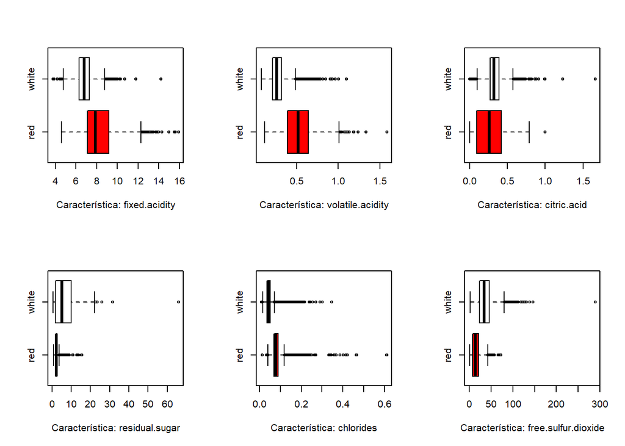

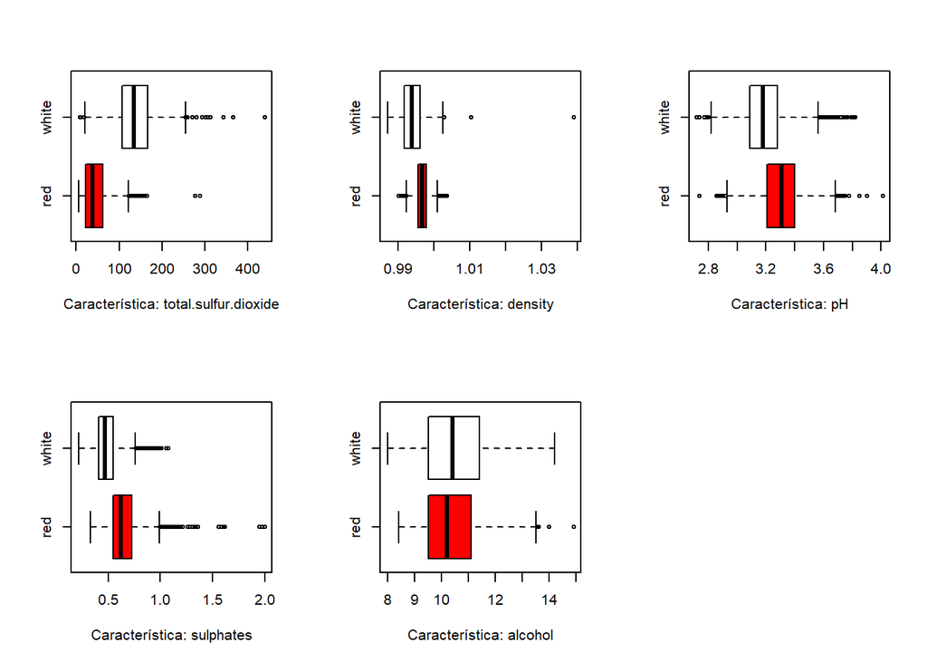

```r
# construye los boxplot de para el conjunto columnas suministradas como parametro
plotBoxplotMultiple = function(wine_quality, colnames) {
  par(mfrow=c(2,3))
  for (col in colnames) {
    boxplot(wine_quality[,col]~type,
         data=wine_quality,
         xlab=paste("Característica", sep = ": ",col),
         horizontal=TRUE,
         col=c("red", "white"))
  }
}

# Detección valores extremos haciendo uso de boxplots
# (sectorizando por tipo de vino)
colnames = names(wine_quality.base[1:11]);
plotBoxplotMultiple(wine_quality.base, colnames)
```

Para tener una visión más detallada de los valores más reseñables involucrados en los diagramas de cajas, obtenemos algunos estadísticos descriptivos haciendo uso de la función summary.

Empezamos con el vino tinto:

```r
# Obtención de estadísticos descriptivos - para tipos de vino tinto
summary(wine_quality.base[wine_quality.base$type=="red",][1:12])
```

```
##  fixed.acidity   volatile.acidity  citric.acid    residual.sugar
##  Min.   : 4.60   Min.   :0.1200   Min.   :0.000   Min.   : 0.900
##  1st Qu.: 7.10   1st Qu.:0.3900   1st Qu.:0.090   1st Qu.: 1.900
##  Median : 7.90   Median :0.5200   Median :0.260   Median : 2.200
##  Mean   : 8.32   Mean   :0.5278   Mean   :0.271   Mean   : 2.539
##  3rd Qu.: 9.20   3rd Qu.:0.6400   3rd Qu.:0.420   3rd Qu.: 2.600
##  Max.   :15.90   Max.   :1.5800   Max.   :1.000   Max.   :15.500
##    chlorides       free.sulfur.dioxide total.sulfur.dioxide
##  Min.   :0.01200   Min.   : 1.00       Min.   :  6.00
##  1st Qu.:0.07000   1st Qu.: 7.00       1st Qu.: 22.00
##  Median :0.07900   Median :14.00       Median : 38.00
##  Mean   :0.08747   Mean   :15.87       Mean   : 46.47
##  3rd Qu.:0.09000   3rd Qu.:21.00       3rd Qu.: 62.00
##  Max.   :0.61100   Max.   :72.00       Max.   :289.00
##     density             pH          sulphates         alcohol
##  Min.   :0.9901   Min.   :2.740   Min.   :0.3300   Min.   : 8.40
##  1st Qu.:0.9956   1st Qu.:3.210   1st Qu.:0.5500   1st Qu.: 9.50
##  Median :0.9968   Median :3.310   Median :0.6200   Median :10.20
##  Mean   :0.9967   Mean   :3.311   Mean   :0.6581   Mean   :10.42
##  3rd Qu.:0.9978   3rd Qu.:3.400   3rd Qu.:0.7300   3rd Qu.:11.10
##  Max.   :1.0037   Max.   :4.010   Max.   :2.0000   Max.   :14.90
##     quality
##  Min.   :3.000
##  1st Qu.:5.000
##  Median :6.000
##  Mean   :5.636
##  3rd Qu.:6.000
##  Max.   :8.000
```

Y continuamos con el vino blanco:

```r
# Obtención de estadísticos descriptivos - para tipos de vino blanco
summary(wine_quality.base[wine_quality.base$type=="white",][1:12])
```

```
##  fixed.acidity    volatile.acidity  citric.acid     residual.sugar
##  Min.   : 3.800   Min.   :0.0800   Min.   :0.0000   Min.   : 0.600
##  1st Qu.: 6.300   1st Qu.:0.2100   1st Qu.:0.2700   1st Qu.: 1.700
##  Median : 6.800   Median :0.2600   Median :0.3200   Median : 5.200
##  Mean   : 6.855   Mean   :0.2782   Mean   :0.3342   Mean   : 6.391
##  3rd Qu.: 7.300   3rd Qu.:0.3200   3rd Qu.:0.3900   3rd Qu.: 9.900
##  Max.   :14.200   Max.   :1.1000   Max.   :1.6600   Max.   :65.800
##    chlorides       free.sulfur.dioxide total.sulfur.dioxide
##  Min.   :0.00900   Min.   :  2.00      Min.   :  9.0
##  1st Qu.:0.03600   1st Qu.: 23.00      1st Qu.:108.0
##  Median :0.04300   Median : 34.00      Median :134.0
##  Mean   :0.04577   Mean   : 35.31      Mean   :138.4
##  3rd Qu.:0.05000   3rd Qu.: 46.00      3rd Qu.:167.0
##  Max.   :0.34600   Max.   :289.00      Max.   :440.0
##     density             pH          sulphates         alcohol
##  Min.   :0.9871   Min.   :2.720   Min.   :0.2200   Min.   : 8.00
##  1st Qu.:0.9917   1st Qu.:3.090   1st Qu.:0.4100   1st Qu.: 9.50
##  Median :0.9937   Median :3.180   Median :0.4700   Median :10.40
##  Mean   :0.9940   Mean   :3.188   Mean   :0.4898   Mean   :10.51
##  3rd Qu.:0.9961   3rd Qu.:3.280   3rd Qu.:0.5500   3rd Qu.:11.40
##  Max.   :1.0390   Max.   :3.820   Max.   :1.0800   Max.   :14.20
##     quality
##  Min.   :3.000
##  1st Qu.:5.000
##  Median :6.000
##  Mean   :5.878
##  3rd Qu.:6.000
##  Max.   :9.000
```

Además, haciendo uso de toda esta información, podemos obtener una tabla resumen del análisis de los outliers aplicables a la distribución de cada característica, en función del tipo de vino:

```r
# Definición de función para recuperar los outliers para un tipo de vino y atributo
getOutliers= function (wine_quality, wine_type, col) {
  return(boxplot.stats(wine_quality[wine_quality$type==wine_type,][,col])$out)
}
# Definición de función para extraer un resumen del análisis de outliers
getOutliersTableInfo = function (wine_quality, colnames) {
  # cabecera
  rowHeader = list("type", "att", "left outliers", "max left", "right outliers", "min right")
  # inicialización data.frame con los resultados
  df = data.frame(rowHeader,stringsAsFactors = F)
  # se itera por los atributos
  for (col in colnames) {
    # se itera por los tipos de vino
    for (wine_type in c("red", "white")) {
      # Valores outliers para la distribución de 'fixed.acidity' - vino tinto
      outliers = getOutliers(wine_quality, wine_type, col)
      # Valor Q1 para atributo y tipo de vino
      firstQu= summary(wine_quality[wine_quality$type==wine_type,][,col])[["1st Qu."]]
      # Valor Q3 para atributo y tipo de vino
      thirdQu=summary(wine_quality[wine_quality$type==wine_type,][,col])[["3rd Qu."]]
      # Número de outliers a la izquierda
      leftOutliers = length(outliers[outliers < firstQu])
      # Máximo valor outliers a la izquierda
      if(leftOutliers > 0) { maxLeftOutliers =  max(outliers[outliers < firstQu]) }
      else { maxLeftOutliers = 0 }
      # Número de outliers a la derecha
      rightOutliers = length(outliers[outliers > thirdQu])
      # Mínimo valor outliers a la derecha
      if(rightOutliers > 0) { minRightOutliers = min(outliers[outliers > thirdQu]) }
      else { minRightOutliers = 0 }
      # Crear fila de datos y añadir al data.frame
      row = list(wine_type, col, leftOutliers, maxLeftOutliers, rightOutliers, minRightOutliers);
      df= rbind(df,row)
    }

  }
  return(df)
}
# obetner las columnas sobre las que se desea analizar los outliers
colnames = names(wine_quality.base[1:11])
# invocar el análisis e imprimir el resultado
res = getOutliersTableInfo(wine_quality.base, colnames)
kable(res)
```

| X.type. | X.att. | X.left.outliers. | X.max.left. | X.right.outliers. | X.min.right. |
| --- | --- | --- | --- | --- | --- |
| type | att | left outliers | max left | right outliers | min right |
| red | fixed.acidity | 0 | 0 | 49 | 12.4 |
| white | fixed.acidity | 14 | 4.7 | 105 | 8.9 |
| red | volatile.acidity | 0 | 0 | 19 | 1.02 |
| white | volatile.acidity | 0 | 0 | 186 | 0.49 |
| red | citric.acid | 0 | 0 | 1 | 1 |
| white | citric.acid | 85 | 0.09 | 185 | 0.58 |
| red | residual.sugar | 0 | 0 | 155 | 3.7 |
| white | residual.sugar | 0 | 0 | 7 | 22.6 |
| red | chlorides | 9 | 0.039 | 103 | 0.12 |
| white | chlorides | 7 | 0.014 | 201 | 0.072 |
| red | free.sulfur.dioxide | 0 | 0 | 30 | 43 |
| white | free.sulfur.dioxide | 0 | 0 | 50 | 81 |
| red | total.sulfur.dioxide | 0 | 0 | 55 | 124 |
| white | total.sulfur.dioxide | 5 | 19 | 14 | 256 |
| red | density | 21 | 0.9922 | 24 | 1.0014 |
| white | density | 0 | 0 | 5 | 1.00295 |
| red | pH | 14 | 2.92 | 21 | 3.69 |
| white | pH | 9 | 2.8 | 66 | 3.57 |
| red | sulphates | 0 | 0 | 59 | 1 |
| white | sulphates | 0 | 0 | 124 | 0.77 |
| red | alcohol | 0 | 0 | 13 | 13.5666666666667 |
| white | alcohol | 0 | 0 | 0 | 0 |

En la tabla resultante, para cada tipo de vino y propiedad podemos encontrar el número de *outliers* a la izquierda y a la derecha de la distribución, así como el valor máximo de los *outliers* a la izquierda, y el mínimo de los *outliers* a la derecha, algo que facilita muchísimo comprender las características de los valores extremos existentes.

A partir de toda esta información podremos analizar los datos de *outliers* encontrados, característica por característica del vino, por ejemplo, si nos fijamos en la acidez fija del vino (**fixed.acidity**), podemos observar que:

- para vinos **tintos**, el 50% de la población se encuetra entre los valores 7,10 y 9,20 de acided fija, hallándose un total de 49 *outliers* a la derecha, donde el valor mínimo de este conjunto de *outliers* es 12.4.
- para vinos **blancos**, el 50% de la población se encuentra entre los valores 6,30 y 7,30, hallándose un total de 14 *outliers* a la izquierda, con un valor máximo de este grupo de *outliers* de 4,7; así como encontrándose un total de 105 *outliers* a la derecha, con un valor mínimo de este otro grupo de *outliers* de 8,9.

Y si además estamos interesados en obtener la lista completa de *outliers*, podremos hacerlo de la siguiente forma:

```r
# Outliers para la propiedad 'fixed.acidity' - tipo de vino tinto
print(getOutliers(wine_quality.base, "red", "fixed.acidity"))
```

```
##  [1] 12.8 12.8 15.0 15.0 12.5 13.3 13.4 12.4 12.5 13.8 13.5 12.6 12.5 12.8
## [15] 12.8 14.0 13.7 13.7 12.7 12.5 12.8 12.6 15.6 12.5 13.0 12.5 13.3 12.4
## [29] 12.5 12.9 14.3 12.4 15.5 15.5 15.6 13.0 12.7 13.0 12.7 12.4 12.7 13.2
## [43] 13.2 13.2 15.9 13.3 12.9 12.6 12.6
```

```r
# Outliers para la propiedad 'fixed.acidity' - tipo de vino blanco
print(getOutliers(wine_quality.base, "white", "fixed.acidity"))
```

```
##   [1]  9.8  9.8 10.2  9.1 10.0  9.2  9.2  9.0  9.1  9.2 10.3  9.4  9.2  9.8
##  [15]  9.6  9.2  9.0  9.3  9.2  9.1  8.9  9.8  8.9  9.2  9.7  9.4 10.3  9.6
##  [29]  9.0  9.7  9.2  9.4  9.6  9.2  9.0  9.2 10.7 10.7  9.0  9.2  9.8  9.2
##  [43] 14.2  8.9  8.9  9.1  9.1  9.8  9.0  9.3  8.9  9.0  9.0  8.9  9.0  9.3
##  [57]  9.2  9.6  9.4  9.4 10.0  8.9  8.9 10.0  9.2  9.2  9.2  9.9  9.5  9.0
##  [71]  9.0  8.9  9.5 11.8  9.4  9.1  9.8  9.9  9.2  8.9  9.2  9.4  9.4  9.4
##  [85]  4.6  8.9  9.4  9.2  9.2  9.8  9.0  9.0  9.0  8.9  8.9  4.5  9.2  9.6
##  [99]  4.2  9.7  9.7  9.0  4.2  9.4  8.9  8.9  8.9  4.7  4.7  3.8  4.4  4.7
## [113]  9.0  9.0  4.7  4.4  3.9  4.7  4.4
```

Ahora que contamos con toda esta información, procede determinar cómo se va a actuar frente a los valores outliers detectados.

De igual forma que en el apartado de Datos Perdidos, puesto que no se cuenta con un conocimiento especializado del rango de valores apropiado para cada uno de las características, y dado que estamos en un ámbito formativo y el mayor reto es suponer los valores como incorrectos o inapropiados, ya que eso implicará tener que aplicar alguna estrategia para su resolución, se van a interpretar los valores outliers encontrados como datos incorrectos.

Las estrategias posibles serán del mismo tipo que las que pueden seguirse para la resolución de datos perdidos, en el próximo apartado, se procederá a aplicar las estrategias apropiadas tanto sobre datos perdidos, como sobre valores outliers.

#### Correcciones problemáticas encontradas

Tras realizarse el análisis de datos perdidos y valores extremos, se han localizado un conjunto de valores que han decidido considerarse datos perdidos y/o erróneos, y para los que en este apartado aplicaremos una estrategia de resolución.

En general, las principales vías para afrontar la resolución de datos perdidos y/o erróneos, son:

- eliminar los registros donde se localiza el valor,
- imputar valor según una de las estrategias habituales

En nuestro caso, aun disponiéndose de un número suficientemente alto de observaciones, vamos a suponer que no deseamos perder información, y que se prefiere asignar un valor tratando de que ese valor se asemeje el máximo a un posible valor real no considerado como erróneo. En este caso, se puede utilizar una técnica de imputación que haga uso de la mayor cantidad de información para predecir los valores perdidos, **missForest** es uno de los métodos más robustos que cumple estos requisitos, y que además goza de amplia popularidad, por lo que aplicaremos este método.

En primer lugar, vamos a asignar valor ‘NA’ a todos los datos que estamos considerando como perdidos y/o erróneos, para posteriormente pasar a aplicar un método de imputación de valores perdidos.

```r
# hacemos una copia del data frame base sobre la que vamos a realizar la limpieza
wine_quality.clean = data.frame(wine_quality.base)

# asignamos valor NA
# - a los valores 0 del atributo 'citric.acid'
wine_quality.clean[wine_quality.base$citric.acid==0,]$citric.acid = NA

# - a los valores outliers para 'fixed.acidity' y tipo de vino 'red'
wine_quality.clean[wine_quality.clean$type=="red" &
                         wine_quality.clean$fixed.acidity>=12.4,]$fixed.acidity = NA
# - a los valores outliers para 'fixed.acidity' y tipo de vino 'white'
wine_quality.clean[wine_quality.clean$type=="white" &
                           wine_quality.clean$fixed.acidity<=4.7,]$fixed.acidity = NA
wine_quality.clean[wine_quality.clean$type=="white" &
                           !is.na(wine_quality.clean$fixed.acidity) & wine_quality.clean$fixed.acidity>=8.9,]$fixed.acidity = NA

# - a los valores outliers para 'volatile.acidity' y tipo de vino 'red'
wine_quality.clean[wine_quality.clean$type=="red" &
                         wine_quality.clean$volatile.acidity>=1.02,]$volatile.acidity = NA
# - a los valores outliers para 'volatile.acidity' y tipo de vino 'white'
wine_quality.clean[wine_quality.clean$type=="white" &
                           wine_quality.clean$volatile.acidity>=0.49,]$volatile.acidity = NA

# - a los valores outliers para 'citric.acid' y tipo de vino 'red'
wine_quality.clean[wine_quality.clean$type=="red" &
                         !is.na(wine_quality.clean$citric.acid) & wine_quality.clean$citric.acid>=1,]$citric.acid = NA
# - a los valores outliers para 'citric.acid' y tipo de vino 'white'
wine_quality.clean[wine_quality.clean$type=="white" &
                           !is.na(wine_quality.clean$citric.acid) & wine_quality.clean$citric.acid<=0.09,]$citric.acid = NA
wine_quality.clean[wine_quality.clean$type=="white" &
                           !is.na(wine_quality.clean$citric.acid) & wine_quality.clean$citric.acid>=0.58,]$citric.acid = NA

# - a los valores outliers para 'residual.sugar' y tipo de vino 'red'
wine_quality.clean[wine_quality.clean$type=="red" &
                         wine_quality.clean$residual.sugar>=3.7,]$residual.sugar = NA
# - a los valores outliers para 'residual.sugar' y tipo de vino 'white'
wine_quality.clean[wine_quality.clean$type=="white" &
                           wine_quality.clean$residual.sugar>=22.6,]$residual.sugar = NA

# - a los valores outliers para 'chlorides' y tipo de vino 'red'
wine_quality.clean[wine_quality.clean$type=="red" &
                         wine_quality.clean$chlorides<=0.039,]$chlorides = NA
wine_quality.clean[wine_quality.clean$type=="red" &
                         !is.na(wine_quality.clean$chlorides) & wine_quality.clean$chlorides>=0.12,]$chlorides = NA
# - a los valores outliers para 'chlorides' y tipo de vino 'white'
wine_quality.clean[wine_quality.clean$type=="white" &
                           wine_quality.clean$chlorides<=0.014,]$chlorides = NA
wine_quality.clean[wine_quality.clean$type=="white" &
                           !is.na(wine_quality.clean$chlorides) & wine_quality.clean$chlorides>=0.072,]$chlorides = NA

# - a los valores outliers para 'free.sulfur.dioxide' y tipo de vino 'red'
wine_quality.clean[wine_quality.clean$type=="red" &
                         wine_quality.clean$free.sulfur.dioxide>=43,]$free.sulfur.dioxide = NA
# - a los valores outliers para 'free.sulfur.dioxide' y tipo de vino 'white'
wine_quality.clean[wine_quality.clean$type=="white" &
                           wine_quality.clean$free.sulfur.dioxide>=81,]$free.sulfur.dioxide = NA

# - a los valores outliers para 'total.sulfur.dioxide' y tipo de vino 'red'
wine_quality.clean[wine_quality.clean$type=="red" &
                         wine_quality.clean$total.sulfur.dioxide>=124,]$total.sulfur.dioxide = NA
# - a los valores outliers para 'total.sulfur.dioxide' y tipo de vino 'white'
wine_quality.clean[wine_quality.clean$type=="white" &
                           wine_quality.clean$total.sulfur.dioxide<=19,]$total.sulfur.dioxide = NA
wine_quality.clean[wine_quality.clean$type=="white" &
                           !is.na(wine_quality.clean$total.sulfur.dioxide) & wine_quality.clean$total.sulfur.dioxide>=256,]$total.sulfur.dioxide = NA

# - a los valores outliers para 'density' y tipo de vino 'red'
wine_quality.clean[wine_quality.clean$type=="red" &
                         wine_quality.clean$density<=0.9922,]$density = NA
wine_quality.clean[wine_quality.clean$type=="red" &
                         !is.na(wine_quality.clean$density) & wine_quality.clean$density>=1.0014,]$density = NA
# - a los valores outliers para 'fixed.acidity' y tipo de vino 'white'
wine_quality.clean[wine_quality.clean$type=="white" &
                           wine_quality.clean$density>=1.00295,]$density = NA

# - a los valores outliers para 'pH' y tipo de vino 'red'
wine_quality.clean[wine_quality.clean$type=="red" &
                         wine_quality.clean$pH<=2.92,]$pH = NA
wine_quality.clean[wine_quality.clean$type=="red" &
                         !is.na(wine_quality.clean$pH) & wine_quality.clean$pH>=3.69,]$pH = NA
# - a los valores outliers para 'pH' y tipo de vino 'white'
wine_quality.clean[wine_quality.clean$type=="white" &
                           wine_quality.clean$pH<=2.8,]$pH = NA
wine_quality.clean[wine_quality.clean$type=="white" &
                           !is.na(wine_quality.clean$pH) & wine_quality.clean$pH>=3.57,]$pH = NA

# - a los valores outliers para 'sulphates' y tipo de vino 'red'
wine_quality.clean[wine_quality.clean$type=="red" &
                         wine_quality.clean$sulphates>=1,]$sulphates = NA
# - a los valores outliers para 'sulphates' y tipo de vino 'white'
wine_quality.clean[wine_quality.clean$type=="white" &
                           wine_quality.clean$sulphates>=0.77,]$sulphates = NA

# - a los valores outliers para 'alcohol' y tipo de vino 'red'
wine_quality.clean[wine_quality.clean$type=="red" &
                         wine_quality.clean$alcohol>=13.5666666666667,]$alcohol = NA
```

Ahora visualizamos los valores perdidos que acabamos de provocar:

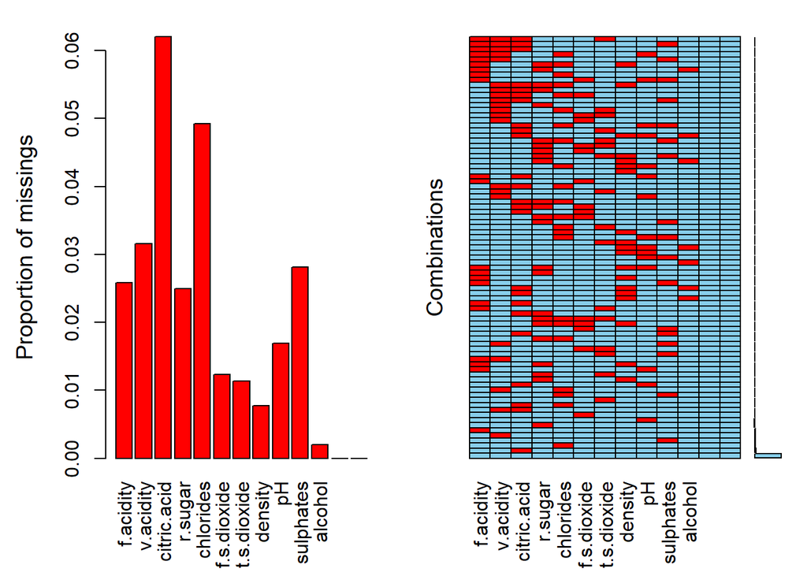

```r
# renombramos algunos titulos para que puedan aparecer en el gráfico
orinal_names = names(wine_quality.clean)
names(wine_quality.clean) = c("f.acidity", "v.acidity", "citric.acid", "r.sugar", "chlorides", "f.s.dioxide", "t.s.dioxide", "density", "pH", "sulphates", "alcohol")
# pintamos gráfico con informacón de missing values
aggr(wine_quality.clean)
```

```r
# asignamos nombre originales
names(wine_quality.clean) = orinal_names
```

Y a continuación se procederá a aplicar el método de imputación escogido:

```r
# Aplicamos método 'missForest' para imputar valores perdidos
imp = missForest(wine_quality.clean)
```

```
##   missForest iteration 1 in progress...done!
##   missForest iteration 2 in progress...done!
##   missForest iteration 3 in progress...done!
##   missForest iteration 4 in progress...done!
##   missForest iteration 5 in progress...done!
```

```r
# Revisamos valores imputados
head(imp$ximp)
```

```
##   fixed.acidity volatile.acidity citric.acid residual.sugar chlorides
## 1           7.4             0.70      0.1095            1.9     0.076
## 2           7.8             0.88      0.2299            2.6     0.098
## 3           7.8             0.76      0.0400            2.3     0.092
## 4          11.2             0.28      0.5600            1.9     0.075
## 5           7.4             0.70      0.1095            1.9     0.076
## 6           7.4             0.66      0.1229            1.8     0.075
##   free.sulfur.dioxide total.sulfur.dioxide density   pH sulphates alcohol
## 1                  11                   34  0.9978 3.51      0.56     9.4
## 2                  25                   67  0.9968 3.20      0.68     9.8
## 3                  15                   54  0.9970 3.26      0.65     9.8
## 4                  17                   60  0.9980 3.16      0.58     9.8
## 5                  11                   34  0.9978 3.51      0.56     9.4
## 6                  13                   40  0.9978 3.51      0.56     9.4
##   quality type
## 1       5  red
## 2       5  red
## 3       5  red
## 4       6  red
## 5       5  red
## 6       5  red
```

```r
# Asignamos el valor imputado  sobre el dataset.clean
wine_quality.clean$fixed.acidity = imp$ximp$fixed.acidity
wine_quality.clean$volatile.acidity = imp$ximp$volatile.acidity
wine_quality.clean$citric.acid = imp$ximp$citric.acid
wine_quality.clean$residual.sugar = imp$ximp$residual.sugar
wine_quality.clean$chlorides = imp$ximp$chlorides
wine_quality.clean$free.sulfur.dioxide = imp$ximp$free.sulfur.dioxide
wine_quality.clean$total.sulfur.dioxide = imp$ximp$total.sulfur.dioxide
wine_quality.clean$density = imp$ximp$density
wine_quality.clean$pH = imp$ximp$pH
wine_quality.clean$sulphates = imp$ximp$sulphates
wine_quality.clean$alcohol = imp$ximp$alcohol
# Verificamos que se han imputado correctamente todos los valores
length(which(is.na(wine_quality.clean)))
```

```
## [1] 0
```

Como vemos, se han logrado imputar todos los valores adecuadamente.

*Nota: Se ha de tener en cuenta que aplicar cambios sobre los valores del dataset puede implicar perdida de información. Aunque en el ámbito de esta práctica, por motivos formativos hemos decidido tratar una serie de datos como valores erróneos o perdidos, en un contexto real, en caso de no disponerse de la posibilidad de consultar a un experto en la materia, la mejor opción sería realizar distintas pruebas llevando a cabo el análisis tanto con los datos originales, como con datos corregidos. De esta forma se facilitará la comprensión de los datos y de en qué medida se ve afectado un resultado analítico por los cambios en los mismos*.

### Selección y reducción de los datos

Una vez han sido realizadas las tareas de tratamiento de datos perdidos y valores extremos, se va a realizar una selección y reducción de los datos.

Con el fin de poder realizar estudios comparativos entre vinos de tipo tinto y blanco, sobre un número equivalente de observaciones, se van a aplicar un mecanismo de reducción de la cantidad, para obtener el mismo número de muestras para vino blanco, que las que disponemos para vino tinto.

En concreto se aplicará una técnica de **sampling** (de tipo muestreo aleatorio simple sin sustitución), que es una vía simple para obtener el resultado deseado:

```r
# seleccionamos vinos tintos
wine_quality_red.clean = wine_quality.clean[wine_quality.clean$type=="red",]

# seleccionamos una muestra de vinos blancos
# - establecemos semilla (esto permitirá que el resultado sea reproducible)
set.seed(10)
# - generamos la muestra aplicando un muestreo aleatorio simple sin sustitución
wine_quality_white.clean = sample_n(wine_quality.clean[wine_quality.clean$type=="white",], 1599, replace = FALSE)

# creamos un unico dataset a partir de los dos previos
wine_quality.clean.total = wine_quality.clean
wine_quality.clean = data.frame(wine_quality_red.clean)
wine_quality.clean = rbind(wine_quality.clean, wine_quality_white.clean)
```

Respecto a los atributos a considerar, en principio no se van a realizar tareas para llevar a cabo una reducción de la dimensionalidad, ya que se desea poder trabajar con el conjunto completo de características para facilitar el análisis de en qué medida afecta cada característica a la calidad de los vinos resultantes.

*Nota: se ha preferido realizar esta fase tras el paso de tratamiento de datos perdidos y valores extremos, ya que en esa fase se aplican mecanismo para imputación de valores que darán mejor resultando contando con la mayor cantidad de información.*

### Conversiones

Finalmente, previo a comenzar con el análisis de los datos, se estudia si conviene realizar algún tipo de transformación sobre los datos que pueda ayudar a que los posteriores análisis sean más eficientes, y/o puedan facilitar la comprensión de los resultados.

Con el objetivo de mejorar la comprensión del resultado de alguno de los análisis se va a generar un nuevo atributo, a partir de la discretización del atributo de calidad, estableciéndose los siguientes rangos: • low: [1-4] • medium: [5-6] • high: [7-10]

```r
# Estandarización
# - Quality level 'low' : [1-4]
wine_quality.clean$quality_level[wine_quality.clean$quality >= 1 & wine_quality.clean$quality <= 4] = "low"
# - Quality level 'medium' : [5-6]
wine_quality.clean$quality_level[wine_quality.clean$quality >= 5 & wine_quality.clean$quality <= 6] = "medium"
# - Quality level 'high' : [7-10]
wine_quality.clean$quality_level[wine_quality.clean$quality >= 7 & wine_quality.clean$quality <= 10] = "high"

wine_quality.clean$quality_level = as.factor(wine_quality.clean$quality_level)
```

```r
# Normalización de los atributos numéricos
wine_quality.clean.scaled = as.data.frame(scale(wine_quality.clean[1:11]))
wine_quality.clean.scaled$quality = wine_quality.clean$quality
wine_quality.clean.scaled$quality_level = wine_quality.clean$quality_level
wine_quality.clean.scaled$type = wine_quality.clean$type
```

### Exportación de los datos preprocesados

Una vez hemos realizado todas las tareas para la limpieza de los datos, procedemos a volcarlos, para tener un juego de datos limpio del que partir para posteriores análisis.

Se llevará a cabo el volcado tanto del dataset estandarizado como no estandarizado, para poder hacer uso de los datos en el formato que convenga según la tarea a ser realizada.

```r
# Escritura en .csv de los datos sin estandarizar
write.csv(wine_quality.clean, "datasets/wine_quality.csv",row.names=FALSE)
# Escritura en .csv de los datos estandarizarizados
write.csv(wine_quality.clean.scaled, "datasets/wine_quality_scaled.csv",row.names=FALSE)
```

## Análisis exploratorio

### Selección grupos de datos a analizar

```r
wine_quality.clean.scaled = read.csv("datasets/wine_quality_scaled.csv")
wine_quality_red.clean.scaled = wine_quality.clean.scaled[wine_quality.clean.scaled$type == "red",]
wine_quality_white.clean.scaled = wine_quality.clean.scaled[wine_quality.clean.scaled$type == "white",]

wine_quality.clean = read.csv("datasets/wine_quality.csv")
wine_quality_red.clean = wine_quality.clean.scaled[wine_quality.clean.scaled$type == "red",]
wine_quality_white.clean = wine_quality.clean.scaled[wine_quality.clean.scaled$type == "white",]
```

### Comprobación de la normalidad y homogeneidad de la varianza

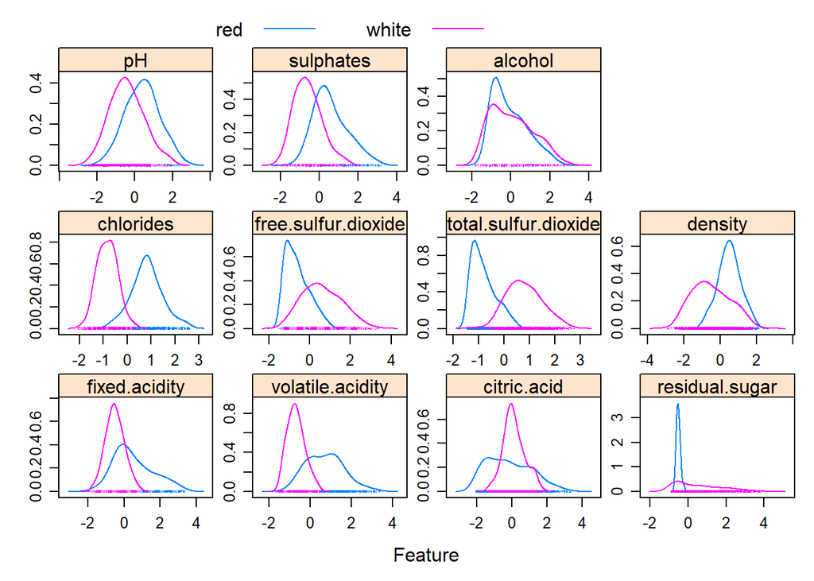

```r
# construir un plot con los diagramas de densidad por características y tipo de vino
wine_quality = wine_quality.clean.scaled
featurePlot(x = wine_quality[, 1:11],
            y = wine_quality$type, plot = "density",
            scales = list(x = list(relation="free"), y = list(relation="free")),
            adjust = 1.5, pch = ".",
            layout = c(4, 3), auto.key = list(columns = 3))
```

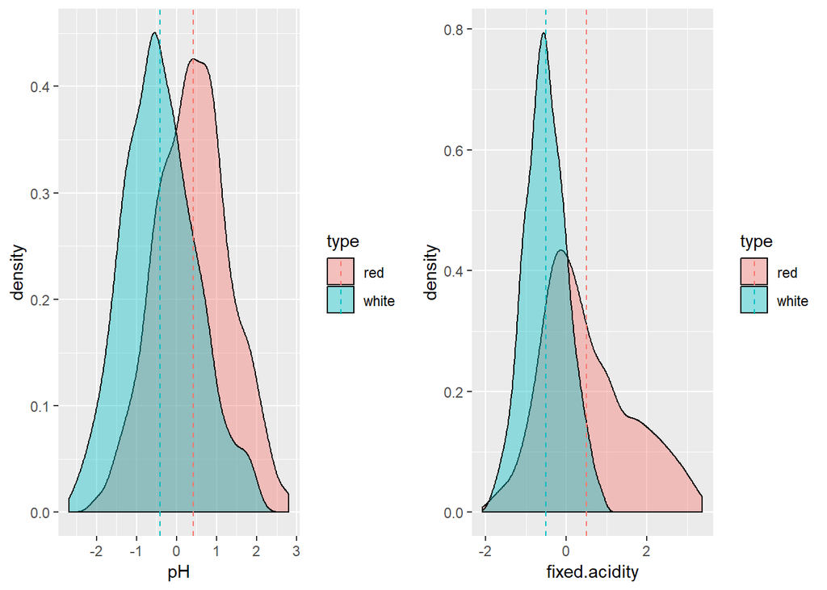

```r
# diagrama de densidad para el 'pH' por tipo de vino, indicando valor central
mu = ddply(wine_quality, "type", summarise, grp.mean=mean(pH))
plot1 = ggplot(wine_quality, aes(x=pH, fill=type)) +
                               geom_density(alpha=0.4) +
                               geom_vline(data=mu, aes(xintercept=grp.mean, color=type),linetype="dashed")
# diagrama de densidad para el 'fixed.acidity' por tipo de vino, indicando valor central
mu = ddply(wine_quality, "type", summarise, grp.mean=mean(fixed.acidity))
plot2 = ggplot(wine_quality, aes(x=fixed.acidity, fill=type)) +
                               geom_density(alpha=0.4) +
                               geom_vline(data=mu, aes(xintercept=grp.mean, color=type),linetype="dashed")

grid.arrange(plot1, plot2, ncol=2)
```

```r
# definición función para ejecutar test de normalidad sobre los atributos
# del dataset de vinos, en función del tipo de vino, y retornar los resultados
getNormlityTestInfo = function(wine_quality, colnames, alpha) {
  # cabecera
  rowHeader = list("tipo","att", "ad.p_val", "ad.test", "shapiro.p_val", "shapiro.test")
  # inicialización datma.frame con los resultados
  df = data.frame(rowHeader,stringsAsFactors = F)

  # se itera por las características del vino
  for (col in colnames) {
    # se itera por los tipos de vino
    for (wine_type in c("red", "white")) {
      ad.p_val = ad.test(wine_quality[wine_quality$type==wine_type,][,col])$p.value
      shapiro.p_val = shapiro.test(wine_quality[wine_quality$type==wine_type,][,col])$p.value
      ad.result = 'yes'
      if(ad.p_val < alpha) {
        ad.result = 'no'
      }
      shapiro.result = 'yes'
      if(shapiro.p_val < alpha) {
        shapiro.result = 'no'
      }
      row = list(wine_type, col, ad.p_val, ad.result, shapiro.p_val, shapiro.result);
      df= rbind(df,row)
    }
  }
  return(df)
}

# se ejecuta la función para pasar los test de normalidad
colnames = names(wine_quality.clean.scaled[1:12]);
alpha = 0.05
infoNormalityTest = getNormlityTestInfo(wine_quality.clean.scaled, colnames, alpha)
kable(infoNormalityTest)
```

| X.tipo. | X.att. | X.ad.p_val. | X.ad.test. | X.shapiro.p_val. | X.shapiro.test. |
| --- | --- | --- | --- | --- | --- |
| tipo | att | ad.p_val | ad.test | shapiro.p_val | shapiro.test |
| red | fixed.acidity | 3.7e-24 | no | 5.14257038442647e-19 | no |
| white | fixed.acidity | 6.74962097609112e-05 | no | 0.000191560563862063 | no |
| red | volatile.acidity | 1.34966583947451e-09 | no | 2.75394419552837e-09 | no |
| white | volatile.acidity | 1.13104442653476e-13 | no | 5.26794320734676e-12 | no |
| red | citric.acid | 3.7e-24 | no | 9.03031452921877e-21 | no |
| white | citric.acid | 3.7e-24 | no | 5.38575687485466e-13 | no |
| red | residual.sugar | 1.77011546089662e-19 | no | 4.74493928637685e-14 | no |
| white | residual.sugar | 3.7e-24 | no | 3.89660030567117e-31 | no |
| red | chlorides | 1.08896224006865e-08 | no | 2.28846904535024e-07 | no |
| white | chlorides | 0.000488693483030147 | no | 0.00216257607177748 | no |
| red | free.sulfur.dioxide | 3.7e-24 | no | 4.57848275814221e-26 | no |
| white | free.sulfur.dioxide | 1.42135416631183e-12 | no | 9.82048783249672e-11 | no |
| red | total.sulfur.dioxide | 3.7e-24 | no | 6.27832165341143e-28 | no |
| white | total.sulfur.dioxide | 2.23000800067791e-09 | no | 1.26764350840662e-07 | no |
| red | density | 0.0152896872187927 | no | 0.000215412037859896 | no |
| white | density | 1.84694316740473e-19 | no | 3.6441060237705e-13 | no |
| red | pH | 0.0202929827002085 | no | 0.00305988891304845 | no |
| white | pH | 2.00199679134304e-06 | no | 2.32301319820327e-07 | no |
| red | sulphates | 3.7e-24 | no | 3.20645227893457e-17 | no |
| white | sulphates | 1.65128545558572e-16 | no | 3.33549852431817e-13 | no |
| red | alcohol | 3.7e-24 | no | 6.43624082667815e-26 | no |
| white | alcohol | 3.7e-24 | no | 2.95638295392193e-21 | no |
| red | quality | 3.7e-24 | no | 9.51508538364454e-36 | no |
| white | quality | 3.7e-24 | no | 1.02968548473584e-32 | no |

A continuación realizamos la verificación de la homogeneidad de la varianza

```r
#wine_quality.clean.scaled$quality = as.numeric(wine_quality.clean.scaled$quality)
fligner.test(quality~type, data = wine_quality.clean.scaled)
```

```
##
##  Fligner-Killeen test of homogeneity of variances
##
## data:  quality by type
## Fligner-Killeen:med chi-squared = 1.8516, df = 1, p-value = 0.1736
```

### Aplicación de pruebas estadísticas

#### Comparación entre grupos

```r
t.test(wine_quality_red.clean.scaled$quality, wine_quality_white.clean.scaled$quality, alternative = "less")
```

```
##
##  Welch Two Sample t-test
##
## data:  wine_quality_red.clean.scaled$quality and wine_quality_white.clean.scaled$quality
## t = -8.1955, df = 3176.2, p-value < 2.2e-16
## alternative hypothesis: true difference in means is less than 0
## 95 percent confidence interval:
##        -Inf -0.1949365
## sample estimates:
## mean of x mean of y
##  5.636023  5.879925
```

Ahora vamos a comparar la calidad de los vinos entre los grupos de vinos tinto y blanco, para ver si hay diferencias significativas (Prueba de Mann-Whitney):

```r
wilcox.test(quality~type, data = wine_quality.clean.scaled )
```

```
##
##  Wilcoxon rank sum test with continuity correction
##
## data:  quality by type
## W = 1072500, p-value < 2.2e-16
## alternative hypothesis: true location shift is not equal to 0
```

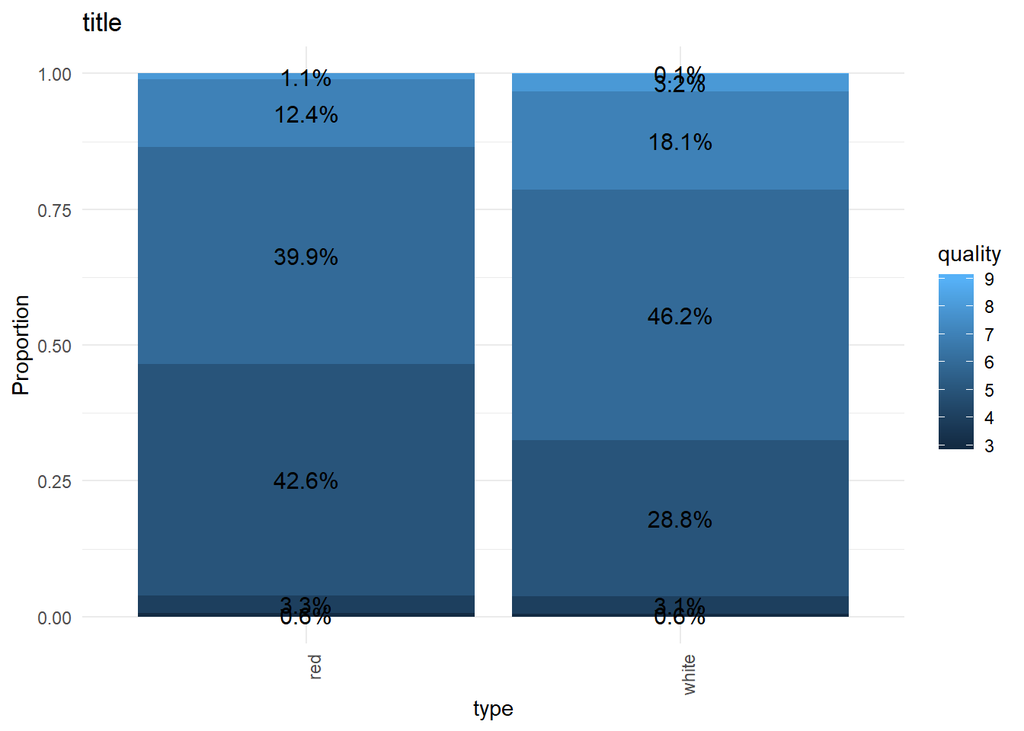

```r
## construye un diagrama de barras de frecuencias para 2 variables
barplotBiVariable = function(dataset, att1, att2, labsize=4) {
  plotdata = dataset %>%
      dplyr::group_by(dataset[,att1], dataset[,att2]) %>%
      dplyr::summarize(n = n()) %>%
      dplyr::mutate(pct = n/sum(n),
             lbl = scales::percent(pct))

  names(plotdata) = c("VAR1", "VAR2", "n", "pct", "lbl")

  ## plot
  plot1 = ggplot(data = plotdata,
                 aes(x = VAR1,
                 y = pct,
                 fill = VAR2,
                 cumulative = TRUE)) +
                 geom_col() +
          labs(y = "Proportion", x=att1, fill=att2, title="title")  +
          geom_text(aes(label = lbl), size=labsize,
                      position = position_stack(vjust = 0.5)) +
          theme_minimal()+
          theme(axis.text.x = element_text(angle = 90, hjust = 1))
  return(plot1)
}
# mostramos una gráfica bi variable por tipo de vino y calidad
plot1 = barplotBiVariable(wine_quality.clean.scaled, "type", "quality")
plot1
```

#### Correlación

Hasta el momento hemos descubierto que los vinos blanco consiguen mejor puntuación de calidad que los vinos tintos, y ahora estamos iteresados en saber ¿que características del vino influyen más en su calidad?.

```r
# Definición de función para extraer un resumen del análisis de outliers
getCorrelationTableInfo = function (wine_quality, colnames) {
  # cabecera
  rowHeader = list("type", "att", "estimate", "p-value")
  # inicialización data.frame con los resultados
  df = data.frame(rowHeader,stringsAsFactors = F)
  # se itera por los atributos
  for (col in colnames) {
    # se itera por los tipos de vino
    for (wine_type in c("red", "white")) {
      # aplicar el test de correlación
      spearman_test = cor.test(wine_quality[wine_quality$type==wine_type,][,col],
                               wine_quality[wine_quality$type==wine_type,]$quality,
                               method="spearman", exact=FALSE)
      correlation_coef = spearman_test$estimate
      p_value = spearman_test$p.value

      # Crear fila de datos y añadir al data.frame
      row = list(wine_type, col, correlation_coef, p_value);
      df= rbind(df,row)
    }
  }
  return(df)
}
# obetner las columnas sobre las que se desea analizar los outliers
colnames = names(wine_quality.base[1:11])
# invocar el análisis e imprimir el resultado
res = getCorrelationTableInfo(wine_quality.clean.scaled, colnames)
kable(res)
```

| X.type. | X.att. | X.estimate. | X.p.value. |
| --- | --- | --- | --- |
| type | att | estimate | p-value |
| red | fixed.acidity | 0.115117924872555 | 3.9304230691117e-06 |
| white | fixed.acidity | -0.0392412424709464 | 0.11675606412932 |
| red | volatile.acidity | -0.374243034049627 | 2.50668523295274e-54 |
| white | volatile.acidity | -0.187207834953186 | 4.45620589346223e-14 |
| red | citric.acid | 0.215896817257208 | 2.55641239337547e-18 |
| white | citric.acid | 0.0728223049301388 | 0.00357317738254749 |
| red | residual.sugar | 0.0406288466483607 | 0.104365995091766 |
| white | residual.sugar | -0.0793501231609543 | 0.0014955807705594 |
| red | chlorides | -0.184363956770903 | 1.08377976311392e-13 |
| white | chlorides | -0.276096430483016 | 2.2853396727652e-29 |
| red | free.sulfur.dioxide | -0.0547724097194498 | 0.0285138690371896 |
| white | free.sulfur.dioxide | 0.0232034801435939 | 0.353797602122699 |
| red | total.sulfur.dioxide | -0.194270945239971 | 4.61018473400712e-15 |
| white | total.sulfur.dioxide | -0.171999075039823 | 4.38768743232005e-12 |
| red | density | -0.180867744495011 | 3.17004607413871e-13 |
| white | density | -0.324225085642727 | 1.86443206504735e-40 |
| red | pH | -0.0474207121818755 | 0.0579839441033872 |
| white | pH | 0.105748976530202 | 2.26308764673605e-05 |
| red | sulphates | 0.414863187596712 | 1.51899033958484e-67 |
| white | sulphates | -0.0090741337576518 | 0.716921930581874 |
| red | alcohol | 0.479488540218924 | 1.05255399131826e-92 |
| white | alcohol | 0.422945113944542 | 2.11498301086771e-70 |

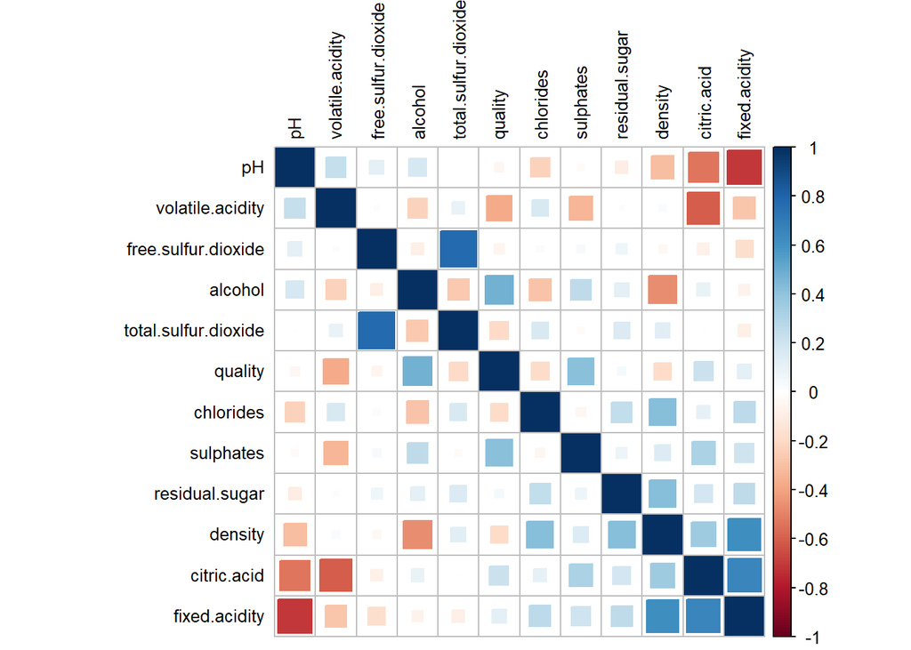

```r
# función para realizar plot de la correlación, seggún el método suministado
# como parámetro (por defecto 'spearman')
plotCorrelation = function(wine_quality, method="spearman") {
  nc=ncol(wine_quality )
  df <- wine_quality [,1:12]
  correlations <- cor(df,method="spearman")
  corrplot(correlations, number.cex = .9, method = "square",
                 hclust.method = "ward", order = "FPC",
                 type = "full", tl.cex=0.8,tl.col = "black")
}

# plot de correlación para vino tinto
wine_quality = wine_quality_red.clean.scaled
plotCorrelation(wine_quality)
```

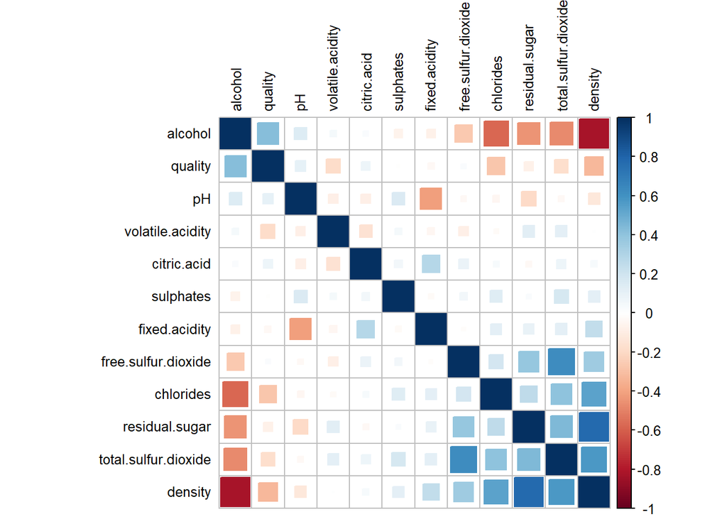

```r
# plot de correlación para vino blanco
wine_quality = wine_quality_white.clean.scaled
plotCorrelation(wine_quality)
```

#### Clasificación

```r
## constucción modelo CART

# se seleccionan los datos usados para la construcción del modelo
# (incluye solo características)
wine_quality = data.frame(wine_quality_red.clean[c(1:11,13)])
#wine_quality$quality = as.factor(wine_quality$quality )
# Se establece una semilla para que los resultados sean reproducibles
set.seed(10)
## partimos 75% observaciones para construcción del modelo, 25% para test
split = sample.split(wine_quality$quality_level, SplitRatio = 0.75)
training_set = subset(wine_quality, split == TRUE)
test_set = subset(wine_quality, split == FALSE)

## contruimos los parámetros que necesarios para la construcción del modelo
numatributes = length(training_set)
## variables explicativas
training_setX = training_set[c(1:11)]
test_setX = test_set[c(1:11)]
## variable objetivo
training_setY = training_set[,numatributes] #CLUSTER_RFM_LAB attribute
test_setY = test_set[,numatributes]

## Construimos el modelo
modelCARTIt1 = rpart(formula = quality_level ~ .,
                  data=training_set, method="class")

## Visualizar resultados del entrenamiento
printcp(modelCARTIt1)
```

```
##
## Classification tree:
## rpart(formula = quality_level ~ ., data = training_set, method = "class")
##
## Variables actually used in tree construction:
## [1] alcohol              citric.acid          density
## [4] pH                   residual.sugar       sulphates
## [7] total.sulfur.dioxide volatile.acidity
##
## Root node error: 210/1199 = 0.17515
##
## n= 1199
##
##         CP nsplit rel error  xerror     xstd
## 1 0.066667      0   1.00000 1.00000 0.062673
## 2 0.022222      2   0.86667 0.96667 0.061837
## 3 0.021429      5   0.80000 0.89524 0.059955
## 4 0.014286      7   0.75714 0.87143 0.059298
## 5 0.012698      9   0.72857 0.90000 0.060085
## 6 0.011905     12   0.69048 0.90000 0.060085
## 7 0.010000     14   0.66667 0.90000 0.060085
```

```r
# cálculamos predicciones forzando a que el retorno sea una predicción de la clase más probable
predicted_modelCARTIt1 = predict( modelCARTIt1, test_setX, type="class" )

# mostramos una tabla en la que pueden observarse la ubicación de las predicciones.
modelCARTIt1_pred_table = table(predicted_modelCARTIt1)
modelCARTIt1_pred_table
```

```
## predicted_modelCARTIt1
##   high    low medium
##     40      0    360
```

```r
## matriz de confusión
mat_conf<-table(test_setY,Predicted=predicted_modelCARTIt1)
mat_conf
```

```
##          Predicted
## test_setY high low medium
##    high     18   0     36
##    low       0   0     16
##    medium   22   0    308
```

```r
## realizamos una estimación de la precisión del árbol
print(sprintf("La precisión del árbol es: %.4f %%",100*sum(predicted_modelCARTIt1 == test_setY) / length(predicted_modelCARTIt1)))
```

```
## [1] "La precisión del árbol es: 81.5000 %"
```

```r
## imprimimos las reglas
rpart.rules(modelCARTIt1)
```

```
##  quality_level  high  low medi
##           high [ .72  .00  .28] when alcohol is -0.018 to 0.972 & volatile.acidity <  -0.11                                                                                                 & pH <  0.058
##           high [ .79  .00  .21] when alcohol >=           0.972 & volatile.acidity >=  0.20 & sulphates >= 0.57 & total.sulfur.dioxide >= -0.68
##           high [ .86  .00  .14] when alcohol is -0.018 to 0.972 & volatile.acidity <  -0.11 & sulphates >= 1.32                                                                             & pH >= 0.058 & residual.sugar >= -0.43
##           high [ .89  .00  .11] when alcohol >=           0.972 & volatile.acidity <   0.20 & sulphates >= 0.57 & total.sulfur.dioxide >= -1.21                        & density <   0.0064
##           high [ .95  .00  .05] when alcohol >=           0.972 & volatile.acidity <   0.20 & sulphates >= 0.57 & total.sulfur.dioxide <  -1.21
##           high [1.00  .00  .00] when alcohol >=           0.972 & volatile.acidity >= -0.66 & sulphates <  0.57                                 & citric.acid >= -0.18 & density <  -0.6411
##         medium [ .35  .05  .60] when alcohol >=           0.972 & volatile.acidity >= -0.66 & sulphates <  0.57                                 & citric.acid >= -0.18 & density >= -0.6411
##         medium [ .32  .00  .68] when alcohol >=           0.972 & volatile.acidity >=  0.20 & sulphates >= 0.57 & total.sulfur.dioxide <  -0.68
##         medium [ .32  .00  .68] when alcohol is -0.018 to 0.972 & volatile.acidity <  -0.11 & sulphates >= 1.32                                                                             & pH >= 0.058 & residual.sugar <  -0.43
##         medium [ .20  .00  .80] when alcohol >=           0.972 & volatile.acidity <   0.20 & sulphates >= 0.57 & total.sulfur.dioxide >= -1.21                        & density >=  0.0064
##         medium [ .10  .03  .86] when alcohol is -0.018 to 0.972 & volatile.acidity <  -0.11 & sulphates <  1.32                                                                             & pH >= 0.058
##         medium [ .09  .04  .87] when alcohol >=           0.972                             & sulphates <  0.57                                 & citric.acid <  -0.18
##         medium [ .11  .00  .89] when alcohol >=           0.972 & volatile.acidity <  -0.66 & sulphates <  0.57                                 & citric.acid >= -0.18
##         medium [ .09  .02  .89] when alcohol <  -0.018          & volatile.acidity <  -0.11
##         medium [ .04  .05  .91] when alcohol <   0.972          & volatile.acidity >= -0.11
```

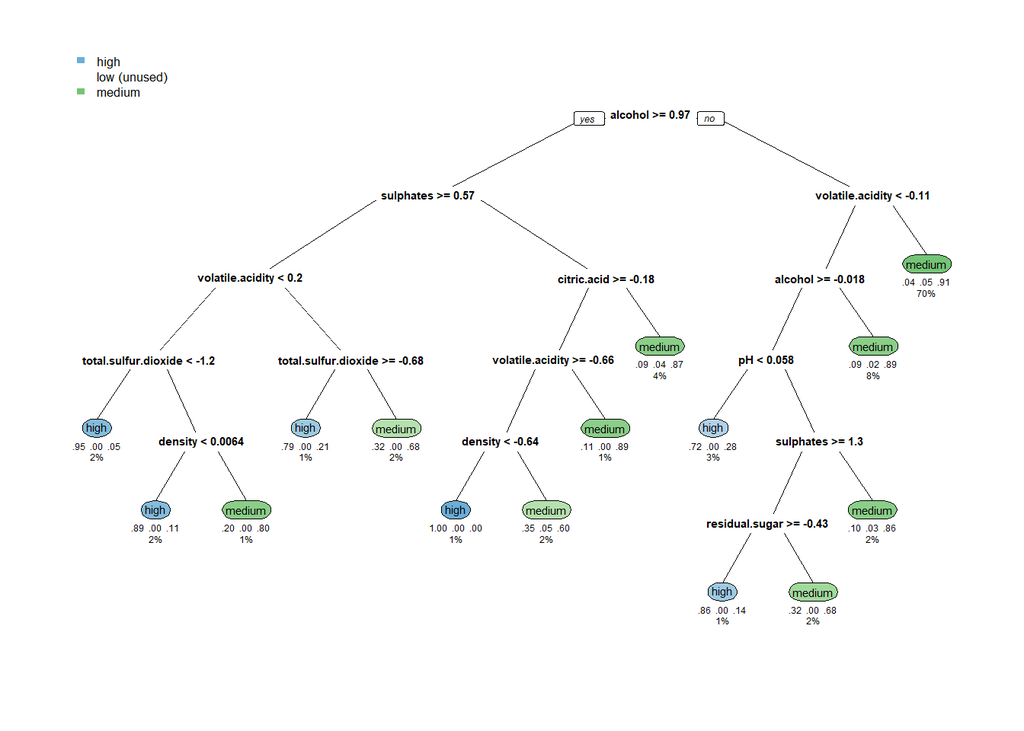

```r
## realizamos plot del árbol resultante
rpart.plot(modelCARTIt1, type = 0, clip.right.lab = FALSE, branch = .3, under = TRUE, box.palette = "auto", tweak = 1.0,  fallen.leaves=FALSE )
```

```r
# se seleccionan los datos usados para la construcción del modelo
# (incluye solo características)
wine_quality = data.frame(wine_quality_white.clean[c(1:11,13)])
#wine_quality$quality = as.factor(wine_quality$quality )
# Se establece una semilla para que los resultados sean reproducibles
set.seed(10)
## partimos 75% observaciones para construcción del modelo, 25% para test
split = sample.split(wine_quality$quality_level, SplitRatio = 0.75)
training_set = subset(wine_quality, split == TRUE)
test_set = subset(wine_quality, split == FALSE)

## contruimos los parámetros que necesarios para la construcción del modelo
numatributes = length(training_set)
## variables explicativas
training_setX = training_set[c(1:11)]
test_setX = test_set[c(1:11)]
## variable objetivo
training_setY = training_set[,numatributes] #CLUSTER_RFM_LAB attribute
test_setY = test_set[,numatributes]

## Construimos el modelo
modelCARTIt2 = rpart(formula = quality_level ~ .,
                  data=training_set, method="class")

## Visualizar resultados del entrenamiento
printcp(modelCARTIt2)
```

```
##
## Classification tree:
## rpart(formula = quality_level ~ ., data = training_set, method = "class")
##
## Variables actually used in tree construction:
## [1] alcohol          chlorides        citric.acid      density
## [5] pH               residual.sugar   sulphates        volatile.acidity
##
## Root node error: 300/1198 = 0.25042
##
## n= 1198
##
##         CP nsplit rel error  xerror     xstd
## 1 0.035000      0   1.00000 1.00000 0.049986
## 2 0.018333      2   0.93000 0.94333 0.049007
## 3 0.012222      9   0.79000 0.96333 0.049361
## 4 0.010000     12   0.75333 0.98667 0.049762
```

```r
# cálculamos predicciones forzando a que el retorno sea una predicción de la clase más probable
predicted_modelCARTIt2 = predict( modelCARTIt2, test_setX, type="class" )

# mostramos una tabla en la que pueden observarse la ubicación de las predicciones.
table(predicted_modelCARTIt2)
```

```
## predicted_modelCARTIt2
##   high    low medium
##     60      0    341
```

```r
## matriz de confusión
mat_conf<-table(test_setY,Predicted=predicted_modelCARTIt2)
mat_conf
```

```
##          Predicted
## test_setY high low medium
##    high     32   0     54
##    low       3   0     12
##    medium   25   0    275
```

```r
## realizamos una estimación de la precisión del árbol
print(sprintf("La precisión del árbol es: %.4f %%",100*sum(predicted_modelCARTIt2 == test_setY) / length(predicted_modelCARTIt2)))
```

```
## [1] "La precisión del árbol es: 76.5586 %"
```

```r
## imprimimos las reglas
rpart.rules(modelCARTIt2)
```

```
##  quality_level  hig low med
##           high [.71 .02 .27] when alcohol >=         2.03
##           high [.73 .00 .27] when alcohol is 0.51 to 2.03 & pH >= -0.97 & volatile.acidity <  -1.20                                                                                               & citric.acid >= -0.18
##           high [.80 .00 .20] when alcohol is 0.51 to 2.03 & pH >= -0.97 & volatile.acidity >=          -0.55 & residual.sugar >= -0.58 & chlorides <  -1.1
##           high [.80 .00 .20] when alcohol is 0.51 to 2.03 & pH >= -0.97 & volatile.acidity >=          -0.55 & residual.sugar >= -0.58 & chlorides >= -1.1 & density <  -1.3
##           high [.82 .00 .18] when alcohol <  0.51         & pH <  -1.75 & volatile.acidity <  -0.94                                                                          & sulphates <  -0.84
##         medium [.18 .18 .65] when alcohol is 0.51 to 2.03 & pH >= -0.97 & volatile.acidity >=          -0.55 & residual.sugar <  -0.58
##         medium [.18 .14 .68] when alcohol is 0.51 to 2.03 & pH >= -0.97 & volatile.acidity >=          -0.55 & residual.sugar >= -0.58 & chlorides >= -1.1 & density >= -1.3
##         medium [.30 .02 .68] when alcohol is 0.51 to 2.03 & pH >= -0.97 & volatile.acidity is -1.20 to -0.55
##         medium [.20 .05 .75] when alcohol is 0.51 to 2.03 & pH <  -0.97
##         medium [.20 .01 .78] when alcohol <  0.51         & pH >= -1.75 & volatile.acidity <  -0.94
##         medium [.12 .00 .88] when alcohol is 0.51 to 2.03 & pH >= -0.97 & volatile.acidity <  -1.20                                                                                               & citric.acid <  -0.18
##         medium [.11 .00 .89] when alcohol <  0.51         & pH <  -1.75 & volatile.acidity <  -0.94                                                                          & sulphates >= -0.84
##         medium [.06 .05 .89] when alcohol <  0.51                       & volatile.acidity >=          -0.94
```

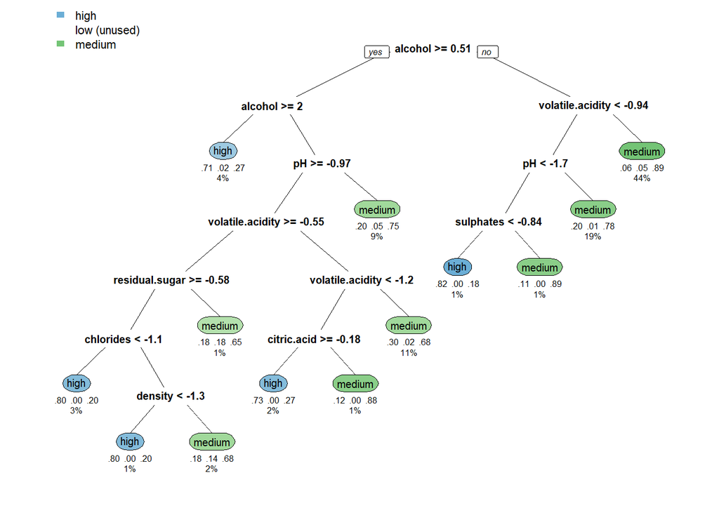

```r
## realizamos plot del árbol resultante
rpart.plot(modelCARTIt2, type = 0, clip.right.lab = FALSE, branch = .3, under = TRUE, box.palette = "auto", tweak = 1.0,  fallen.leaves=FALSE )
```

### Representación y visualización de los datos

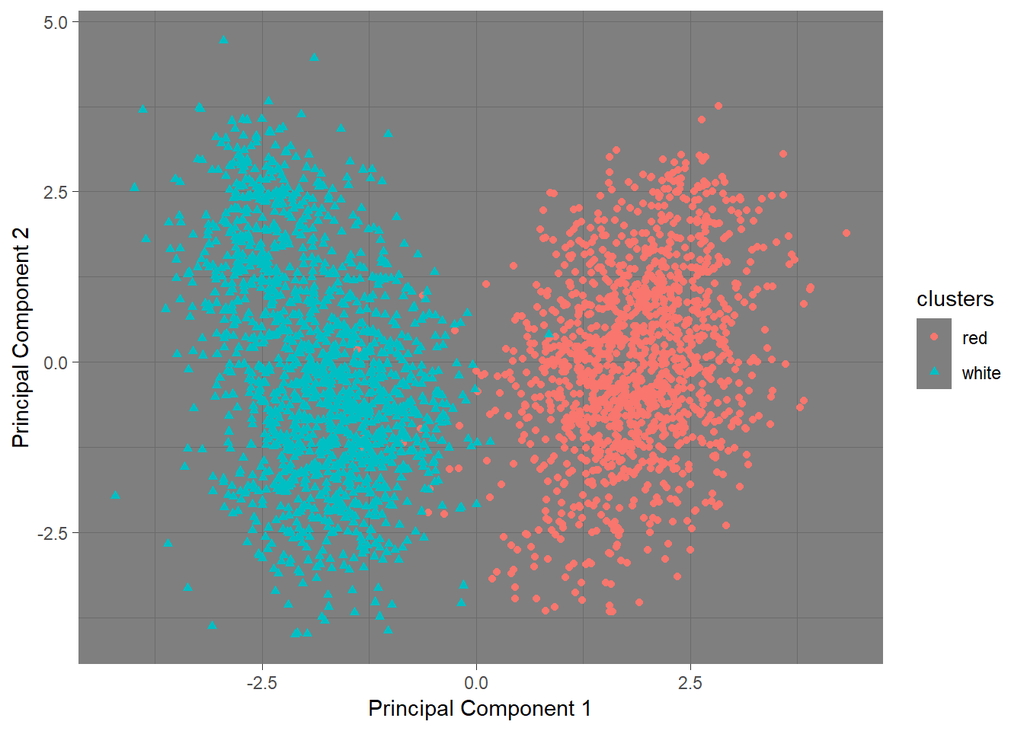

```r
# Inicializo el dataset para realizar el plot PCA y lo ejecuto
wine_quality = wine_quality.clean.scaled[1:11]
plotClusterPCA(wine_quality, wine_quality.clean.scaled, "type")
```

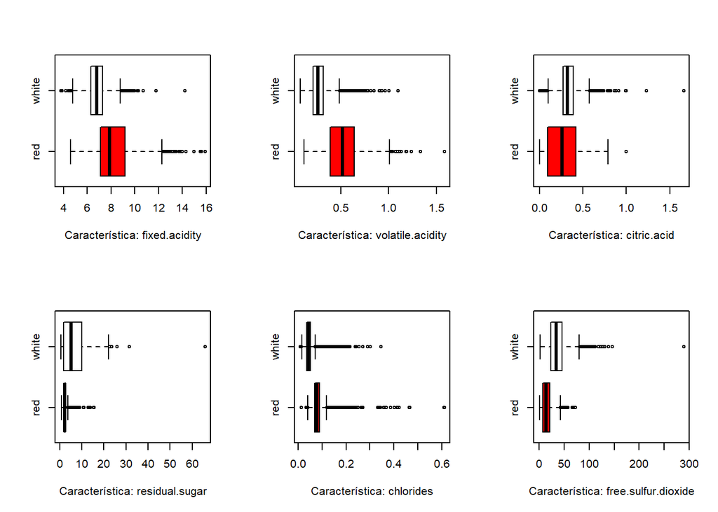

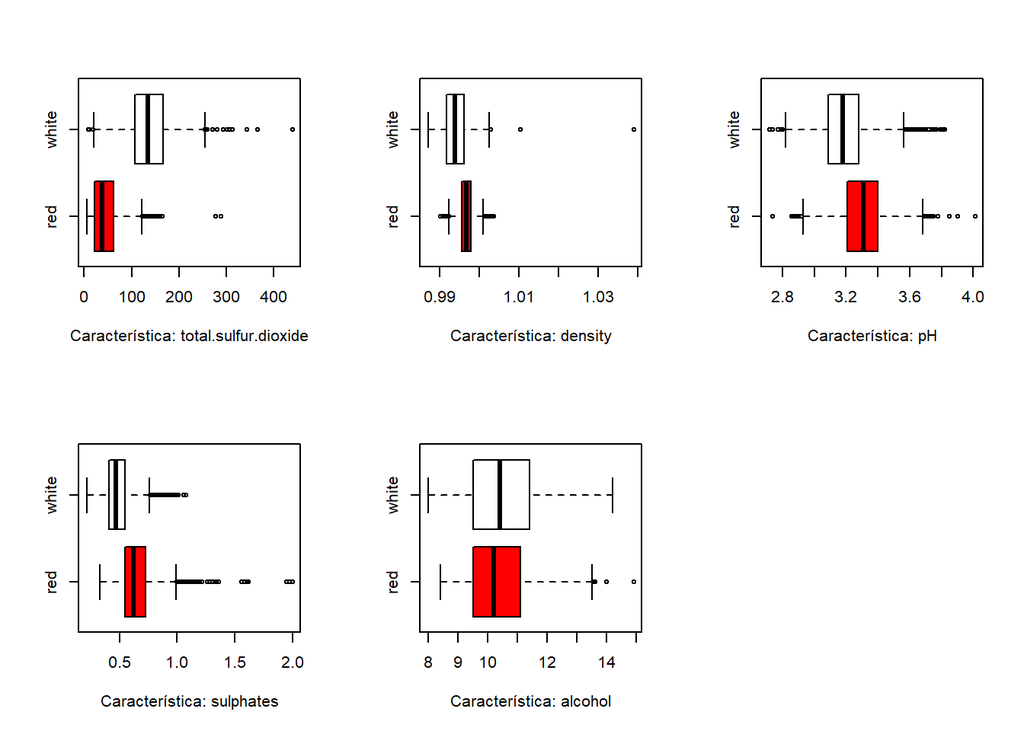

```r
wine_quality = wine_quality.base

# Visualización caracerísticas por tipo de vino
colnames = names(wine_quality[1:11]);
plotBoxplotMultiple(wine_quality, colnames)
```

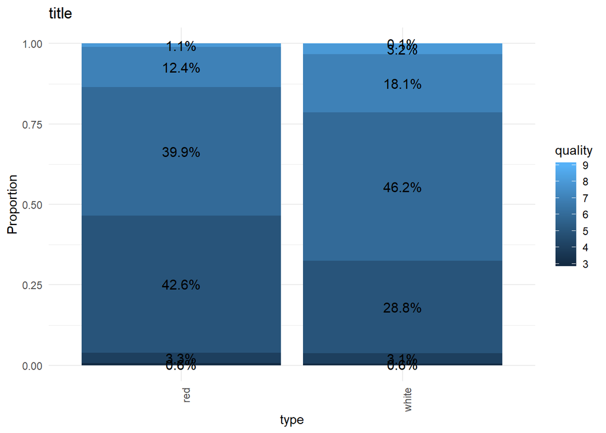

```r
# mostramos una gráfica bi variable por tipo de vino y calidad
barplotBiVariable(wine_quality.clean.scaled, "type", "quality")
```

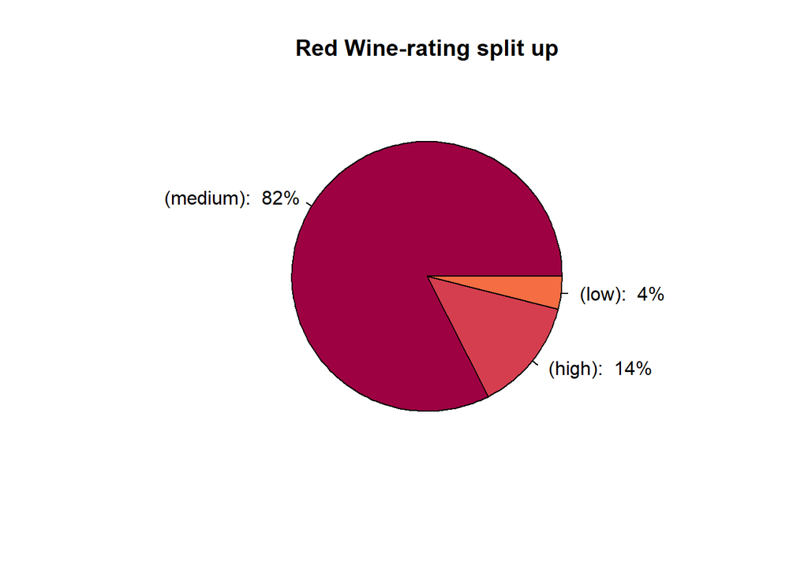

```r
wine_quality = wine_quality.clean.scaled
## Generaremos un gráfico de sectores con la función pie.
pie_values <- sort(table(wine_quality[wine_quality$type=="red",]$quality_level), decreasing = TRUE)
pct = round(pie_values/sum(pie_values)*100)
lbls = c('', '', '')
lbls = paste(lbls,names(pie_values),sep=" (")
lbls = paste(lbls,"): ",sep="")
lbls = paste(lbls, pct) ## añadir porcentajes a las label
lbls = paste(lbls,"%",sep="") ## añadir caracer % a las label
pie(pie_values, labels = lbls, main="Red Wine-rating split up", col=brewer.pal(10, "Spectral"))
```

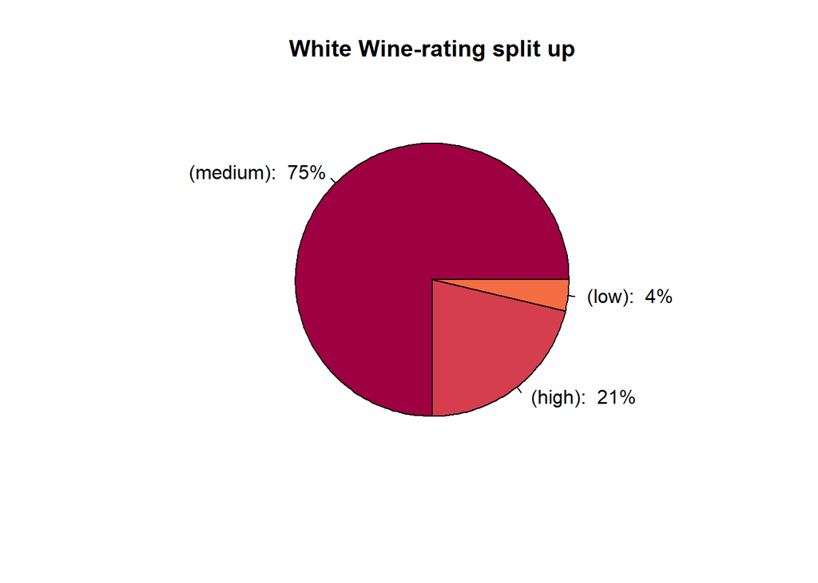

```r
## Generaremos un gráfico de sectores con la función pie.
pie_values <- sort(table(wine_quality[wine_quality$type=="white",]$quality_level), decreasing = TRUE)
pct = round(pie_values/sum(pie_values)*100)
lbls = c('', '', '')
lbls = paste(lbls,names(pie_values),sep=" (")
lbls = paste(lbls,"): ",sep="")
lbls = paste(lbls, pct) ## añadir porcentajes a las label
lbls = paste(lbls,"%",sep="") ## añadir caracer % a las label
pie(pie_values, labels = lbls, main="White Wine-rating split up", col=brewer.pal(10, "Spectral"))
```

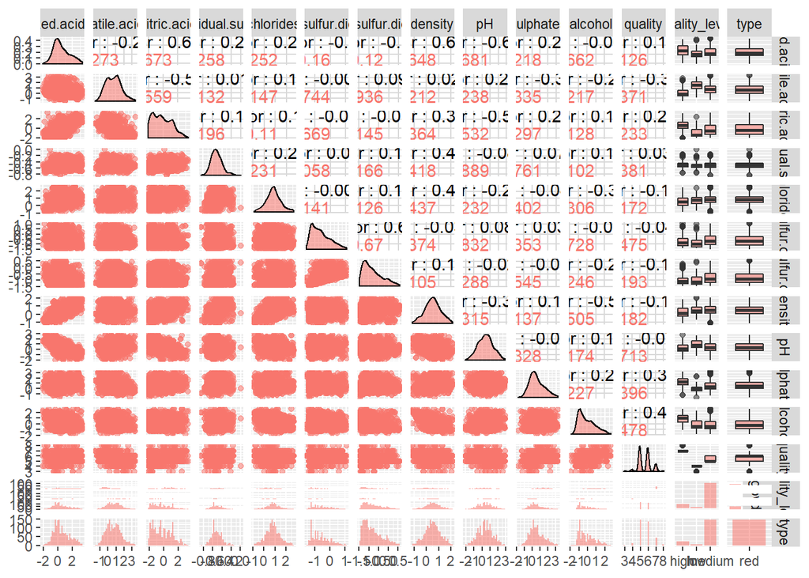

```r
# visualización múltiple
ggpairs(wine_quality_red.clean.scaled, aes(colour = type, alpha = 0.4))
```

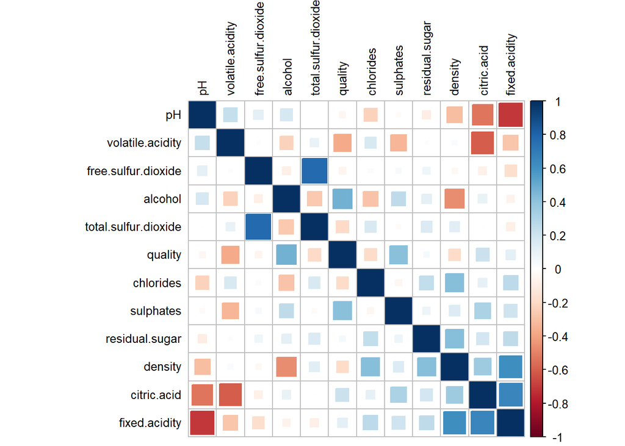

```r
# plot de correlación para vino tinto
wine_quality = wine_quality_red.clean.scaled
plotCorrelation(wine_quality)
```

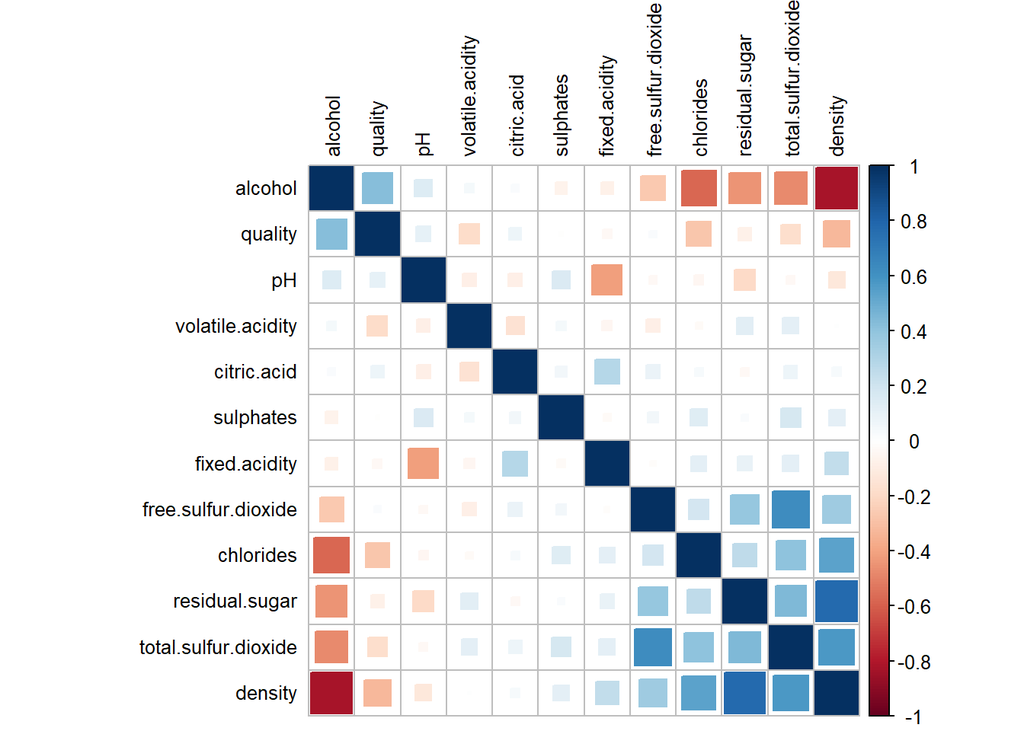

```r
# plot de correlación para vino blanco
wine_quality = wine_quality_white.clean.scaled
plotCorrelation(wine_quality)
```

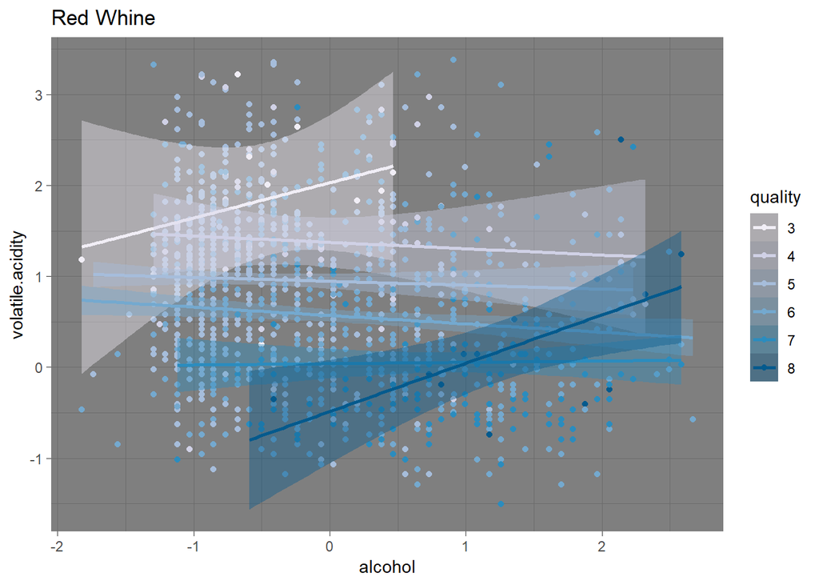

```r
# función para pintar un plot con la regresión lineal entre dos variables, agrupado por quality
plotQualityRegression = function(wine_quality, x_att, y_att, title="") {
  ggplot(wine_quality, aes(x = wine_quality[,x_att], y = wine_quality[,y_att], color = quality, fill = quality)) +
          geom_point() +
          geom_smooth(method = 'lm') +
          scale_fill_brewer(palette = "PuBu") +
          scale_color_brewer(palette = "PuBu") +
          xlab(x_att) + ylab(y_att) +
          labs(title = title) +
          theme_dark()
}
# análisis relación alcohol, volatile.acidity y quality - vino tinto
wine_quality = data.frame(wine_quality_red.clean.scaled)
wine_quality$quality = as.factor(wine_quality$quality)
plotQualityRegression(wine_quality,  "alcohol", "volatile.acidity", "Red Whine")
```

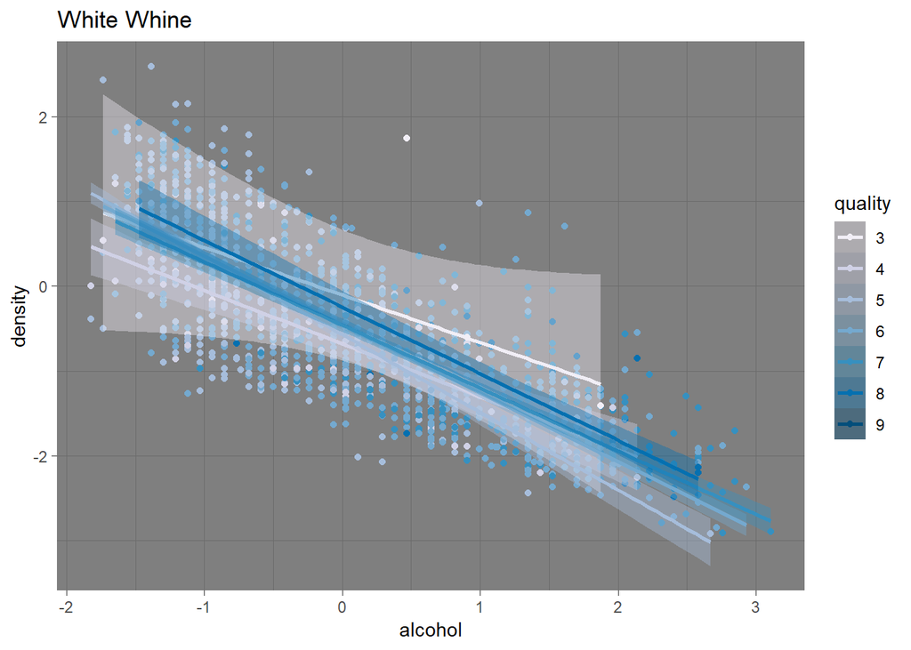

```r
# análisis relación alcohol, volatile.acidity y quality - vino blanco
wine_quality = data.frame(wine_quality_white.clean.scaled)
wine_quality$quality = as.factor(wine_quality$quality)
plotQualityRegression(wine_quality,  "alcohol", "density", "White Whine")
```

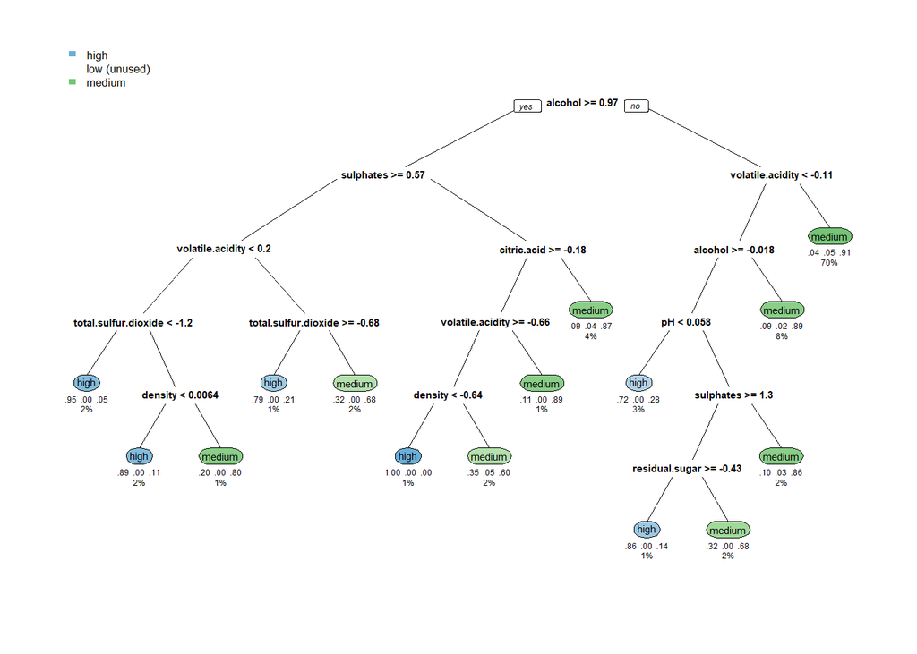

```r
## realizamos plot del árbol de clasificación - vino tinto
rpart.plot(modelCARTIt1, type = 0, clip.right.lab = FALSE, branch = .3, under = TRUE, box.palette = "auto", tweak = 1.0,  fallen.leaves=FALSE )
```

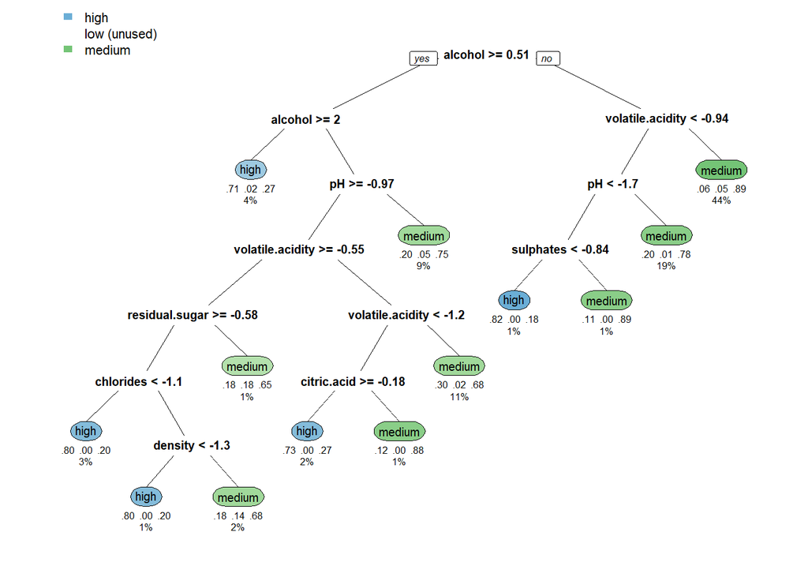

```r
## realizamos plot del árbol de clasificación - vino blanco
rpart.plot(modelCARTIt2, type = 0, clip.right.lab = FALSE, branch = .3, under = TRUE, box.palette = "auto", tweak = 1.0,  fallen.leaves=FALSE )
```

nocite: | Gareth James (2013), Jiawei Han (2012), Jarman (2013), Squire (2015), Calvo M. (2019), W.Osborne (2010) …

# Bibliografía

Calvo M., Pérez D., Subirats L. 2019. *Introducción a La Limpieza Y Análisis de Los Datos*. UOC.

Gareth James, Trevor Hastie, Daniela Witten. 2013. *An Introduction to Statistical Learning*. Firsth Edition. London: Springer.

Jarman, Kristin H. 2013. *The Art of Data Analysis. How to Answer Almost Any Question Using Basic Statistics*. Firsth Edition. Morgan Kaufmann.

Jiawei Han, Jian Pei, Micheline Kamber. 2012. *Data Mining, Concepts and Techniques*. Third Edition. Waltham: Morgan Kaufmann.

Squire, Megan. 2015. *Clean Data*. Packt Publishing Ltd.

W.Osborne, Jason. 2010. *Data Cleaning Basics: Best Practices in Dealing with Extreme Scores. Newborn and Infant Nursing Reviews*.